# ANCOVA in TDE - Escrita (TDE - Escrita)

Geiser C. Challco geiser@alumni.usp.br

- Descriptive Statistics of Initial Data
- ANCOVA and Pairwise for one factor: **grupo**
  - Without remove non-normal data
  - Computing ANCOVA and PairWise After removing non-normal data (OK)
    - Plots for ancova
    - Checking linearity assumption
    - Checking normality and homogeneity
- ANCOVA and Pairwise for two factors **grupo:Sexo**
  - Without remove non-normal data
  - Computing ANCOVA and PairWise After removing non-normal data (OK)
    - Plots for ancova
    - Checking linearity assumption
    - Checking normality and homogeneity
- ANCOVA and Pairwise for two factors **grupo:Zona**
  - Without remove non-normal data
  - Computing ANCOVA and PairWise After removing non-normal data (OK)
    - Plots for ancova
    - Checking linearity assumption
    - Checking normality and homogeneity
- ANCOVA and Pairwise for two factors **grupo:Cor.Raca**
  - Without remove non-normal data
  - Computing ANCOVA and PairWise After removing non-normal data (OK)
    - Plots for ancova
    - Checking linearity assumption
    - Checking normality and homogeneity
- ANCOVA and Pairwise for two factors **grupo:Serie**
  - Without remove non-normal data
  - Computing ANCOVA and PairWise After removing non-normal data (OK)
    - Plots for ancova
    - Checking linearity assumption
    - Checking normality and homogeneity
- Summary of Results
  - Descriptive Statistics
  - ANCOVA Table Comparison
  - PairWise Table Comparison
  - EMMS Table Comparison

**NOTE**:

- Teste ANCOVA para determinar se houve diferenças significativas no TDE - Escrita (medido usando pre- e pos-testes).
- ANCOVA test to determine whether there were significant differences in TDE - Escrita (measured using pre- and post-tests).

# Descriptive Statistics of Initial Data

```r
df <- get.descriptives(dat, c(dv.pre, dv.pos), c("grupo"),
                       include.global = T, symmetry.test = T, normality.test = F)
df <- plyr::rbind.fill(
  df, do.call(plyr::rbind.fill, lapply(lfatores2, FUN = function(f) {
    if (nrow(dat) > 0 && sum(!is.na(unique(dat[[f]]))) > 1)
      get.descriptives(dat, c(dv.pre,dv.pos), c("grupo", f),
                       symmetry.test = T, normality.test = F)
    }))
)
(df <- df[,c(fatores1[fatores1 %in% colnames(df)],"variable",
             colnames(df)[!colnames(df) %in% c(fatores1,"variable")])])
```

```
##           grupo Sexo   Zona Cor.Raca Serie      variable   n   mean median min max     sd    se      ci
## 1      Controle <NA>   <NA>     <NA>  <NA> score.tde.pre  54 38.815   39.5  32  42  3.004 0.409   0.820
## 2  Experimental <NA>   <NA>     <NA>  <NA> score.tde.pre 141 37.383   38.0  32  42  3.177 0.268   0.529
## 3          <NA> <NA>   <NA>     <NA>  <NA> score.tde.pre 195 37.779   38.0  32  42  3.188 0.228   0.450
## 4      Controle <NA>   <NA>     <NA>  <NA> score.tde.pos  54 30.185   28.5   2  62 15.298 2.082   4.176
## 5  Experimental <NA>   <NA>     <NA>  <NA> score.tde.pos 141 34.872   37.0   0  64 13.013 1.096   2.167
## 6          <NA> <NA>   <NA>     <NA>  <NA> score.tde.pos 195 33.574   35.0   0  64 13.804 0.989   1.950
## 7      Controle    F   <NA>     <NA>  <NA> score.tde.pre  36 39.167   40.5  33  42  3.019 0.503   1.021
## 8      Controle    M   <NA>     <NA>  <NA> score.tde.pre  18 38.111   38.0  32  42  2.928 0.690   1.456
## 9  Experimental    F   <NA>     <NA>  <NA> score.tde.pre  61 37.557   38.0  32  42  3.101 0.397   0.794
## 10 Experimental    M   <NA>     <NA>  <NA> score.tde.pre  80 37.250   37.0  32  42  3.247 0.363   0.723
## 11     Controle    F   <NA>     <NA>  <NA> score.tde.pos  36 31.444   29.5   4  62 16.366 2.728   5.538
## 12     Controle    M   <NA>     <NA>  <NA> score.tde.pos  18 27.667   26.5   2  51 12.966 3.056   6.448
## 13 Experimental    F   <NA>     <NA>  <NA> score.tde.pos  61 36.934   39.0   0  64 14.477 1.854   3.708
## 14 Experimental    M   <NA>     <NA>  <NA> score.tde.pos  80 33.300   35.0   8  56 11.623 1.300   2.587
```

[output cut: 98 more lines]

| grupo | Sexo | Zona | Cor.Raca | Serie | variable | n | mean | median | min | max | sd | se | ci | iqr | symmetry | skewness | kurtosis |
| --- | --- | --- | --- | --- | --- | --- | --- | --- | --- | --- | --- | --- | --- | --- | --- | --- | --- |
| Controle |  |  |  |  | score.tde.pre | 54 | 38.815 | 39.5 | 32 | 42 | 3.004 | 0.409 | 0.820 | 5.00 | NO | -0.510 | -1.049 |
| Experimental |  |  |  |  | score.tde.pre | 141 | 37.383 | 38.0 | 32 | 42 | 3.177 | 0.268 | 0.529 | 6.00 | YES | -0.147 | -1.221 |
|  |  |  |  |  | score.tde.pre | 195 | 37.779 | 38.0 | 32 | 42 | 3.188 | 0.228 | 0.450 | 6.00 | YES | -0.246 | -1.183 |
| Controle |  |  |  |  | score.tde.pos | 54 | 30.185 | 28.5 | 2 | 62 | 15.298 | 2.082 | 4.176 | 22.25 | YES | 0.232 | -0.869 |
| Experimental |  |  |  |  | score.tde.pos | 141 | 34.872 | 37.0 | 0 | 64 | 13.013 | 1.096 | 2.167 | 18.00 | YES | -0.298 | -0.483 |
|  |  |  |  |  | score.tde.pos | 195 | 33.574 | 35.0 | 0 | 64 | 13.804 | 0.989 | 1.950 | 19.00 | YES | -0.163 | -0.671 |
| Controle | F |  |  |  | score.tde.pre | 36 | 39.167 | 40.5 | 33 | 42 | 3.019 | 0.503 | 1.021 | 6.00 | NO | -0.609 | -1.239 |
| Controle | M |  |  |  | score.tde.pre | 18 | 38.111 | 38.0 | 32 | 42 | 2.928 | 0.690 | 1.456 | 3.75 | YES | -0.369 | -0.720 |
| Experimental | F |  |  |  | score.tde.pre | 61 | 37.557 | 38.0 | 32 | 42 | 3.101 | 0.397 | 0.794 | 5.00 | YES | -0.161 | -1.252 |
| Experimental | M |  |  |  | score.tde.pre | 80 | 37.250 | 37.0 | 32 | 42 | 3.247 | 0.363 | 0.723 | 6.00 | YES | -0.125 | -1.254 |
| Controle | F |  |  |  | score.tde.pos | 36 | 31.444 | 29.5 | 4 | 62 | 16.366 | 2.728 | 5.538 | 24.25 | YES | 0.188 | -1.145 |
| Controle | M |  |  |  | score.tde.pos | 18 | 27.667 | 26.5 | 2 | 51 | 12.966 | 3.056 | 6.448 | 15.00 | YES | 0.039 | -0.684 |
| Experimental | F |  |  |  | score.tde.pos | 61 | 36.934 | 39.0 | 0 | 64 | 14.477 | 1.854 | 3.708 | 21.00 | YES | -0.358 | -0.586 |
| Experimental | M |  |  |  | score.tde.pos | 80 | 33.300 | 35.0 | 8 | 56 | 11.623 | 1.300 | 2.587 | 17.00 | YES | -0.430 | -0.648 |
| Controle |  | Rural |  |  | score.tde.pre | 23 | 39.522 | 41.0 | 34 | 42 | 2.998 | 0.625 | 1.296 | 5.50 | NO | -0.660 | -1.418 |
| Controle |  | Urbana |  |  | score.tde.pre | 18 | 37.500 | 37.5 | 32 | 42 | 2.662 | 0.628 | 1.324 | 3.50 | YES | -0.318 | -0.688 |
| Controle |  |  |  |  | score.tde.pre | 13 | 39.385 | 40.0 | 33 | 42 | 3.070 | 0.851 | 1.855 | 3.00 | NO | -0.894 | -0.595 |
| Experimental |  | Rural |  |  | score.tde.pre | 64 | 36.719 | 37.0 | 32 | 42 | 3.037 | 0.380 | 0.759 | 5.00 | YES | -0.014 | -1.235 |
| Experimental |  | Urbana |  |  | score.tde.pre | 40 | 38.675 | 39.5 | 33 | 42 | 2.912 | 0.460 | 0.931 | 4.50 | YES | -0.408 | -1.216 |
| Experimental |  |  |  |  | score.tde.pre | 37 | 37.135 | 37.0 | 32 | 42 | 3.351 | 0.551 | 1.117 | 6.00 | YES | -0.093 | -1.373 |
| Controle |  | Rural |  |  | score.tde.pos | 23 | 33.261 | 35.0 | 2 | 62 | 14.464 | 3.016 | 6.255 | 20.00 | YES | -0.136 | -0.682 |
| Controle |  | Urbana |  |  | score.tde.pos | 18 | 20.722 | 19.0 | 4 | 39 | 10.910 | 2.572 | 5.426 | 17.25 | YES | 0.321 | -1.292 |
| Controle |  |  |  |  | score.tde.pos | 13 | 37.846 | 33.0 | 10 | 59 | 16.293 | 4.519 | 9.846 | 25.00 | YES | -0.048 | -1.522 |
| Experimental |  | Rural |  |  | score.tde.pos | 64 | 34.500 | 34.5 | 8 | 64 | 12.866 | 1.608 | 3.214 | 17.75 | YES | 0.113 | -0.508 |
| Experimental |  | Urbana |  |  | score.tde.pos | 40 | 34.075 | 36.5 | 8 | 56 | 13.088 | 2.069 | 4.186 | 18.50 | YES | -0.477 | -0.794 |
| Experimental |  |  |  |  | score.tde.pos | 37 | 36.378 | 40.0 | 0 | 55 | 13.415 | 2.205 | 4.473 | 17.00 | NO | -0.751 | -0.174 |
| Controle |  |  | Branca |  | score.tde.pre | 6 | 38.167 | 38.5 | 35 | 41 | 2.858 | 1.167 | 2.999 | 5.25 | YES | -0.096 | -2.142 |
| Controle |  |  | Indígena |  | score.tde.pre | 2 | 41.500 | 41.5 | 41 | 42 | 0.707 | 0.500 | 6.353 | 0.50 | few data | 0.000 | 0.000 |
| Controle |  |  | Parda |  | score.tde.pre | 22 | 39.045 | 39.5 | 32 | 42 | 3.031 | 0.646 | 1.344 | 5.00 | NO | -0.639 | -0.759 |
| Controle |  |  |  |  | score.tde.pre | 24 | 38.542 | 38.5 | 33 | 42 | 3.120 | 0.637 | 1.318 | 5.25 | YES | -0.347 | -1.361 |
| Experimental |  |  | Branca |  | score.tde.pre | 15 | 37.867 | 38.0 | 32 | 42 | 3.137 | 0.810 | 1.737 | 5.00 | YES | -0.339 | -1.377 |
| Experimental |  |  | Indígena |  | score.tde.pre | 4 | 35.000 | 35.0 | 32 | 38 | 2.944 | 1.472 | 4.684 | 4.50 | YES | 0.000 | -2.354 |
| Experimental |  |  | Parda |  | score.tde.pre | 34 | 37.147 | 38.0 | 32 | 42 | 2.904 | 0.498 | 1.013 | 4.00 | YES | -0.149 | -0.978 |
| Experimental |  |  |  |  | score.tde.pre | 88 | 37.500 | 38.0 | 32 | 42 | 3.291 | 0.351 | 0.697 | 6.00 | YES | -0.153 | -1.337 |
| Controle |  |  | Branca |  | score.tde.pos | 6 | 25.667 | 25.0 | 10 | 43 | 15.188 | 6.200 | 15.939 | 25.75 | YES | 0.033 | -2.227 |
| Controle |  |  | Indígena |  | score.tde.pos | 2 | 40.000 | 40.0 | 31 | 49 | 12.728 | 9.000 | 114.356 | 9.00 | few data | 0.000 | 0.000 |
| Controle |  |  | Parda |  | score.tde.pos | 22 | 29.273 | 28.0 | 2 | 59 | 18.362 | 3.915 | 8.141 | 28.75 | YES | 0.200 | -1.378 |
| Controle |  |  |  |  | score.tde.pos | 24 | 31.333 | 27.5 | 11 | 62 | 12.586 | 2.569 | 5.315 | 13.25 | NO | 0.694 | -0.302 |
| Experimental |  |  | Branca |  | score.tde.pos | 15 | 37.667 | 40.0 | 10 | 64 | 14.316 | 3.696 | 7.928 | 18.00 | YES | -0.183 | -0.841 |
| Experimental |  |  | Indígena |  | score.tde.pos | 4 | 35.250 | 36.5 | 19 | 49 | 15.019 | 7.510 | 23.899 | 23.25 | YES | -0.064 | -2.352 |
| Experimental |  |  | Parda |  | score.tde.pos | 34 | 32.853 | 31.5 | 8 | 62 | 14.347 | 2.460 | 5.006 | 18.50 | YES | 0.145 | -0.761 |
| Experimental |  |  |  |  | score.tde.pos | 88 | 35.159 | 38.0 | 0 | 56 | 12.273 | 1.308 | 2.600 | 15.25 | NO | -0.573 | -0.262 |
| Controle |  |  |  | 6 ano | score.tde.pre | 13 | 38.846 | 40.0 | 35 | 42 | 2.794 | 0.775 | 1.689 | 4.00 | YES | -0.235 | -1.708 |
| Controle |  |  |  | 7 ano | score.tde.pre | 17 | 38.059 | 38.0 | 32 | 42 | 3.491 | 0.847 | 1.795 | 6.00 | YES | -0.345 | -1.465 |
| Controle |  |  |  | 8 ano | score.tde.pre | 17 | 38.824 | 39.0 | 34 | 42 | 2.811 | 0.682 | 1.446 | 5.00 | YES | -0.291 | -1.338 |
| Controle |  |  |  | 9 ano | score.tde.pre | 7 | 40.571 | 42.0 | 36 | 42 | 2.299 | 0.869 | 2.126 | 2.00 | NO | -1.031 | -0.650 |
| Experimental |  |  |  | 6 ano | score.tde.pre | 43 | 37.116 | 37.0 | 32 | 42 | 3.064 | 0.467 | 0.943 | 5.50 | YES | 0.009 | -1.121 |
| Experimental |  |  |  | 7 ano | score.tde.pre | 47 | 37.043 | 37.0 | 32 | 42 | 3.257 | 0.475 | 0.956 | 6.00 | YES | -0.048 | -1.247 |
| Experimental |  |  |  | 8 ano | score.tde.pre | 19 | 37.158 | 38.0 | 32 | 42 | 2.892 | 0.663 | 1.394 | 4.00 | YES | -0.175 | -1.348 |
| Experimental |  |  |  | 9 ano | score.tde.pre | 32 | 38.375 | 40.0 | 32 | 42 | 3.309 | 0.585 | 1.193 | 5.25 | NO | -0.553 | -1.237 |
| Controle |  |  |  | 6 ano | score.tde.pos | 13 | 26.231 | 25.0 | 10 | 51 | 13.230 | 3.669 | 7.995 | 15.00 | NO | 0.630 | -0.852 |
| Controle |  |  |  | 7 ano | score.tde.pos | 17 | 22.882 | 18.0 | 2 | 62 | 17.201 | 4.172 | 8.844 | 20.00 | NO | 0.795 | -0.593 |
| Controle |  |  |  | 8 ano | score.tde.pos | 17 | 36.529 | 36.0 | 19 | 59 | 12.047 | 2.922 | 6.194 | 14.00 | YES | 0.472 | -0.882 |
| Controle |  |  |  | 9 ano | score.tde.pos | 7 | 39.857 | 40.0 | 26 | 56 | 11.539 | 4.361 | 10.672 | 16.50 | YES | 0.105 | -1.755 |
| Experimental |  |  |  | 6 ano | score.tde.pos | 43 | 28.651 | 29.0 | 8 | 50 | 12.002 | 1.830 | 3.694 | 20.50 | YES | -0.052 | -1.091 |
| Experimental |  |  |  | 7 ano | score.tde.pos | 47 | 33.085 | 33.0 | 12 | 62 | 11.738 | 1.712 | 3.446 | 15.50 | YES | 0.095 | -0.583 |
| Experimental |  |  |  | 8 ano | score.tde.pos | 19 | 44.789 | 43.0 | 24 | 64 | 9.790 | 2.246 | 4.719 | 11.50 | YES | 0.050 | -0.522 |
| Experimental |  |  |  | 9 ano | score.tde.pos | 32 | 39.969 | 43.0 | 0 | 57 | 12.800 | 2.263 | 4.615 | 11.75 | NO | -1.358 | 1.721 |

# ANCOVA and Pairwise for one factor: **grupo**

## Without remove non-normal data

```r
pdat = remove_group_data(dat[!is.na(dat[["grupo"]]),], "score.tde.pos", "grupo")

pdat.long <- rbind(pdat[,c("id","grupo")], pdat[,c("id","grupo")])
pdat.long[["time"]] <- c(rep("pre", nrow(pdat)), rep("pos", nrow(pdat)))
pdat.long[["time"]] <- factor(pdat.long[["time"]], c("pre","pos"))
pdat.long[["score.tde"]] <- c(pdat[["score.tde.pre"]], pdat[["score.tde.pos"]])

aov = anova_test(pdat, score.tde.pos ~ score.tde.pre + grupo)
laov[["grupo"]] <- get_anova_table(aov)
```

```r
pwc <- emmeans_test(pdat, score.tde.pos ~ grupo, covariate = score.tde.pre,
                    p.adjust.method = "bonferroni")
```

```r
pwc.long <- emmeans_test(dplyr::group_by_at(pdat.long, "grupo"),
                          score.tde ~ time,
                          p.adjust.method = "bonferroni")
lpwc[["grupo"]] <- plyr::rbind.fill(pwc, pwc.long)
```

```r
ds <- get.descriptives(pdat, "score.tde.pos", "grupo", covar = "score.tde.pre")
ds <- merge(ds[ds$variable != "score.tde.pre",],
            ds[ds$variable == "score.tde.pre", !colnames(ds) %in% c("variable")],
            by = "grupo", all.x = T, suffixes = c("", ".score.tde.pre"))
ds <- merge(get_emmeans(pwc), ds, by = "grupo", suffixes = c(".emms", ""))
ds <- ds[,c("grupo","n","mean.score.tde.pre","se.score.tde.pre","mean","se","emmean","se.emms")]

colnames(ds) <- c("grupo", "N", paste0(c("M","SE")," (pre)"),
                  paste0(c("M","SE"), " (unadj)"), paste0(c("M", "SE"), " (adj)"))

lemms[["grupo"]] <- ds
```

## Computing ANCOVA and PairWise After removing non-normal data (OK)

```r
wdat = pdat

res = residuals(lm(score.tde.pos ~ score.tde.pre + grupo, data = wdat))
non.normal = getNonNormal(res, wdat$id, plimit = 0.05)

wdat = wdat[!wdat$id %in% non.normal,]

wdat.long <- rbind(wdat[,c("id","grupo")], wdat[,c("id","grupo")])
wdat.long[["time"]] <- c(rep("pre", nrow(wdat)), rep("pos", nrow(wdat)))
wdat.long[["time"]] <- factor(wdat.long[["time"]], c("pre","pos"))
wdat.long[["score.tde"]] <- c(wdat[["score.tde.pre"]], wdat[["score.tde.pos"]])

ldat[["grupo"]] = wdat

(non.normal)
```

```r
aov = anova_test(wdat, score.tde.pos ~ score.tde.pre + grupo)
laov[["grupo"]] <- merge(get_anova_table(aov), laov[["grupo"]], by="Effect", suffixes = c("","'"))

(df = get_anova_table(aov))
```

```
## ANOVA Table (type II tests)
##
##          Effect DFn DFd      F        p p<.05   ges
## 1 score.tde.pre   1 192 21.357 6.98e-06     * 0.100
## 2         grupo   1 192  9.837 2.00e-03     * 0.049
```

| Effect | DFn | DFd | F | p | p<.05 | ges |
| --- | --- | --- | --- | --- | --- | --- |
| score.tde.pre | 1 | 192 | 21.357 | 0.000 | * | 0.100 |
| grupo | 1 | 192 | 9.837 | 0.002 | * | 0.049 |

[output not shown]

```r
pwc.long <- emmeans_test(dplyr::group_by_at(wdat.long, "grupo"),
                         score.tde ~ time,
                         p.adjust.method = "bonferroni")
lpwc[["grupo"]] <- merge(plyr::rbind.fill(pwc, pwc.long), lpwc[["grupo"]], by=c("grupo","term",".y.","group1","group2"), suffixes = c("","'"))
```

| grupo | term | .y. | group1 | group2 | df | statistic | p | p.adj | p.adj.signif |
| --- | --- | --- | --- | --- | --- | --- | --- | --- | --- |
| Controle | time | score.tde | pre | pos | 386 | 4.519 | 0.000 | 0.000 | **** |
| Experimental | time | score.tde | pre | pos | 386 | 2.125 | 0.034 | 0.034 | * |

```r
ds <- get.descriptives(wdat, "score.tde.pos", "grupo", covar = "score.tde.pre")
ds <- merge(ds[ds$variable != "score.tde.pre",],
            ds[ds$variable == "score.tde.pre", !colnames(ds) %in% c("variable")],
            by = "grupo", all.x = T, suffixes = c("", ".score.tde.pre"))
ds <- merge(get_emmeans(pwc), ds, by = "grupo", suffixes = c(".emms", ""))
ds <- ds[,c("grupo","n","mean.score.tde.pre","se.score.tde.pre","mean","se","emmean","se.emms")]

colnames(ds) <- c("grupo", "N", paste0(c("M","SE")," (pre)"),
                  paste0(c("M","SE"), " (unadj)"), paste0(c("M", "SE"), " (adj)"))

lemms[["grupo"]] <- merge(ds, lemms[["grupo"]], by=c("grupo"), suffixes = c("","'"))
```

| grupo | N | M (pre) | SE (pre) | M (unadj) | SE (unadj) | M (adj) | SE (adj) |
| --- | --- | --- | --- | --- | --- | --- | --- |
| Controle | 54 | 38.815 | 0.409 | 30.185 | 2.082 | 28.754 | 1.797 |
| Experimental | 141 | 37.383 | 0.268 | 34.872 | 1.096 | 35.420 | 1.102 |

### Plots for ancova

```r
plots <- oneWayAncovaPlots(
  wdat, "score.tde.pos", "grupo", aov, list("grupo"=pwc), addParam = c("mean_se"),
  font.label.size=10, step.increase=0.05, p.label="p.adj",
  subtitle = which(aov$Effect == "grupo"))
```

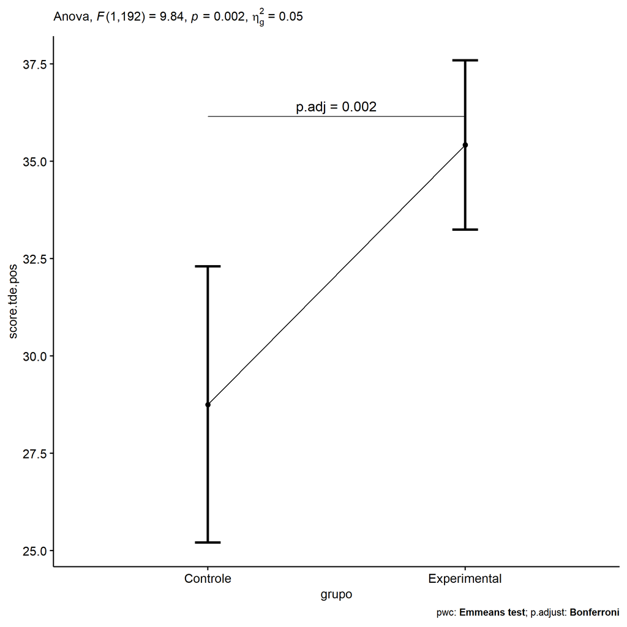

```r
if (!is.null(nrow(plots[["grupo"]]$data)))
  plots[["grupo"]] + ggplot2::scale_color_manual(values = color[["grupo"]])
```

```r
plots <- oneWayAncovaBoxPlots(
  wdat, "score.tde.pos", "grupo", aov, pwc, covar = "score.tde.pre",
  theme = "classic", color = color[["grupo"]],
  subtitle = which(aov$Effect == "grupo"))
```

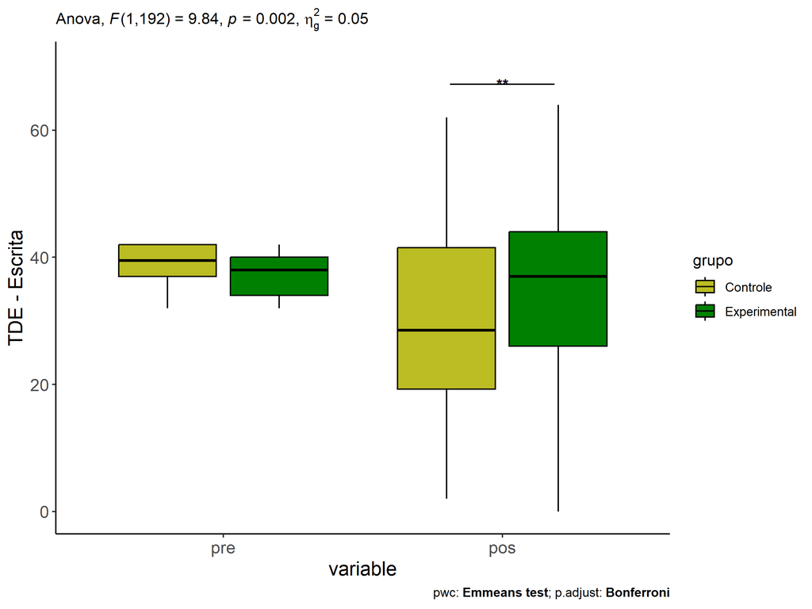

```r
if (length(unique(wdat[["grupo"]])) > 1)
  plots[["grupo"]] + ggplot2::ylab("TDE - Escrita") + ggplot2::scale_x_discrete(labels=c('pre', 'pos'))
```

```r
if (length(unique(wdat.long[["grupo"]])) > 1)
  plots <- oneWayAncovaBoxPlots(
    wdat.long, "score.tde", "grupo", aov, pwc.long, pre.post = "time",
    theme = "classic", color = color$prepost)
```

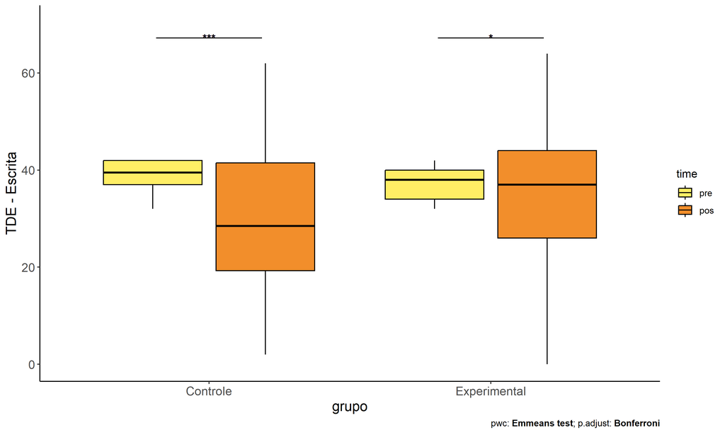

```r
if (length(unique(wdat.long[["grupo"]])) > 1)
  plots[["grupo"]] + ggplot2::ylab("TDE - Escrita")
```

### Checking linearity assumption

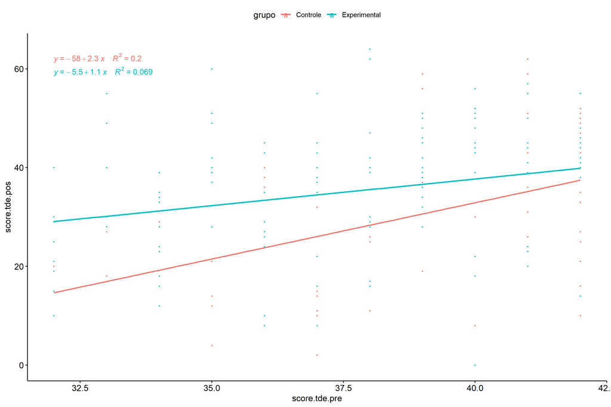

```r
ggscatter(wdat, x = "score.tde.pre", y = "score.tde.pos", size = 0.5,
          color = "grupo", add = "reg.line")+
  stat_regline_equation(
    aes(label =  paste(..eq.label.., ..rr.label.., sep = "~~~~"), color = grupo)
  )
```

### Checking normality and homogeneity

```r
res <- augment(lm(score.tde.pos ~ score.tde.pre + grupo, data = wdat))
```

```r
shapiro_test(res$.resid)
```

```
## # A tibble: 1 × 3
##   variable   statistic p.value
##   <chr>          <dbl>   <dbl>
## 1 res$.resid     0.988  0.0984
```

```r
levene_test(res, .resid ~ grupo)
```

```
## # A tibble: 1 × 4
##     df1   df2 statistic     p
##   <int> <int>     <dbl> <dbl>
## 1     1   193      1.64 0.202
```

# ANCOVA and Pairwise for two factors **grupo:Sexo**

## Without remove non-normal data

```r
pdat = remove_group_data(dat[!is.na(dat[["grupo"]]) & !is.na(dat[["Sexo"]]),], "score.tde.pos", c("grupo","Sexo"))

pdat.long <- rbind(pdat[,c("id","grupo","Sexo")], pdat[,c("id","grupo","Sexo")])
pdat.long[["time"]] <- c(rep("pre", nrow(pdat)), rep("pos", nrow(pdat)))
pdat.long[["time"]] <- factor(pdat.long[["time"]], c("pre","pos"))
pdat.long[["score.tde"]] <- c(pdat[["score.tde.pre"]], pdat[["score.tde.pos"]])

aov = anova_test(pdat, score.tde.pos ~ score.tde.pre + grupo*Sexo)
laov[["grupo:Sexo"]] <- get_anova_table(aov)
```

```r
pwcs <- list()
pwcs[["Sexo"]] <- emmeans_test(
  group_by(pdat, grupo), score.tde.pos ~ Sexo,
  covariate = score.tde.pre, p.adjust.method = "bonferroni")
pwcs[["grupo"]] <- emmeans_test(
  group_by(pdat, Sexo), score.tde.pos ~ grupo,
  covariate = score.tde.pre, p.adjust.method = "bonferroni")

pwc <- plyr::rbind.fill(pwcs[["grupo"]], pwcs[["Sexo"]])
pwc <- pwc[,c("grupo","Sexo", colnames(pwc)[!colnames(pwc) %in% c("grupo","Sexo")])]
```

```r
pwc.long <- emmeans_test(dplyr::group_by_at(pdat.long, c("grupo","Sexo")),
                         score.tde ~ time,
                         p.adjust.method = "bonferroni")
lpwc[["grupo:Sexo"]] <- plyr::rbind.fill(pwc, pwc.long)
```

```r
ds <- get.descriptives(pdat, "score.tde.pos", c("grupo","Sexo"), covar = "score.tde.pre")
ds <- merge(ds[ds$variable != "score.tde.pre",],
            ds[ds$variable == "score.tde.pre", !colnames(ds) %in% c("variable")],
            by = c("grupo","Sexo"), all.x = T, suffixes = c("", ".score.tde.pre"))
ds <- merge(get_emmeans(pwcs[["grupo"]]), ds, by = c("grupo","Sexo"), suffixes = c(".emms", ""))
ds <- ds[,c("grupo","Sexo","n","mean.score.tde.pre","se.score.tde.pre","mean","se","emmean","se.emms")]

colnames(ds) <- c("grupo","Sexo", "N", paste0(c("M","SE")," (pre)"),
                  paste0(c("M","SE"), " (unadj)"), paste0(c("M", "SE"), " (adj)"))

lemms[["grupo:Sexo"]] <- ds
```

## Computing ANCOVA and PairWise After removing non-normal data (OK)

```r
wdat = pdat

res = residuals(lm(score.tde.pos ~ score.tde.pre + grupo*Sexo, data = wdat))
non.normal = getNonNormal(res, wdat$id, plimit = 0.05)

wdat = wdat[!wdat$id %in% non.normal,]

wdat.long <- rbind(wdat[,c("id","grupo","Sexo")], wdat[,c("id","grupo","Sexo")])
wdat.long[["time"]] <- c(rep("pre", nrow(wdat)), rep("pos", nrow(wdat)))
wdat.long[["time"]] <- factor(wdat.long[["time"]], c("pre","pos"))
wdat.long[["score.tde"]] <- c(wdat[["score.tde.pre"]], wdat[["score.tde.pos"]])


ldat[["grupo:Sexo"]] = wdat

(non.normal)
```

```r
aov = anova_test(wdat, score.tde.pos ~ score.tde.pre + grupo*Sexo)
laov[["grupo:Sexo"]] <- merge(get_anova_table(aov), laov[["grupo:Sexo"]], by="Effect", suffixes = c("","'"))

(df = get_anova_table(aov))
```

```
## ANOVA Table (type II tests)
##
##          Effect DFn DFd      F        p p<.05      ges
## 1 score.tde.pre   1 190 20.198 1.21e-05     * 0.096000
## 2         grupo   1 190 11.443 8.71e-04     * 0.057000
## 3          Sexo   1 190  2.468 1.18e-01       0.013000
## 4    grupo:Sexo   1 190  0.039 8.43e-01       0.000208
```

| Effect | DFn | DFd | F | p | p<.05 | ges |
| --- | --- | --- | --- | --- | --- | --- |
| score.tde.pre | 1 | 190 | 20.198 | 0.000 | * | 0.096 |
| grupo | 1 | 190 | 11.443 | 0.001 | * | 0.057 |
| Sexo | 1 | 190 | 2.468 | 0.118 |  | 0.013 |
| grupo:Sexo | 1 | 190 | 0.039 | 0.843 |  | 0.000 |

```r
pwcs <- list()
pwcs[["Sexo"]] <- emmeans_test(
  group_by(wdat, grupo), score.tde.pos ~ Sexo,
  covariate = score.tde.pre, p.adjust.method = "bonferroni")
pwcs[["grupo"]] <- emmeans_test(
  group_by(wdat, Sexo), score.tde.pos ~ grupo,
  covariate = score.tde.pre, p.adjust.method = "bonferroni")

pwc <- plyr::rbind.fill(pwcs[["grupo"]], pwcs[["Sexo"]])
pwc <- pwc[,c("grupo","Sexo", colnames(pwc)[!colnames(pwc) %in% c("grupo","Sexo")])]
```

| grupo | Sexo | term | .y. | group1 | group2 | df | statistic | p | p.adj | p.adj.signif |
| --- | --- | --- | --- | --- | --- | --- | --- | --- | --- | --- |
|  | F | score.tde.pre*grupo | score.tde.pos | Controle | Experimental | 190 | -2.762 | 0.006 | 0.006 | ** |
|  | M | score.tde.pre*grupo | score.tde.pos | Controle | Experimental | 190 | -1.999 | 0.047 | 0.047 | * |
| Controle |  | score.tde.pre*Sexo | score.tde.pos | F | M | 190 | 0.626 | 0.532 | 0.532 | ns |
| Experimental |  | score.tde.pre*Sexo | score.tde.pos | F | M | 190 | 1.457 | 0.147 | 0.147 | ns |

```r
pwc.long <- emmeans_test(dplyr::group_by_at(wdat.long, c("grupo","Sexo")),
                         score.tde ~ time,
                         p.adjust.method = "bonferroni")
lpwc[["grupo:Sexo"]] <- merge(plyr::rbind.fill(pwc, pwc.long), lpwc[["grupo:Sexo"]], by=c("grupo","Sexo","term",".y.","group1","group2"), suffixes = c("","'"))
```

| grupo | Sexo | term | .y. | group1 | group2 | df | statistic | p | p.adj | p.adj.signif |
| --- | --- | --- | --- | --- | --- | --- | --- | --- | --- | --- |
| Controle | F | time | score.tde | pre | pos | 382 | 3.313 | 0.001 | 0.001 | ** |
| Controle | M | time | score.tde | pre | pos | 382 | 3.169 | 0.002 | 0.002 | ** |
| Experimental | F | time | score.tde | pre | pos | 382 | 0.348 | 0.728 | 0.728 | ns |
| Experimental | M | time | score.tde | pre | pos | 382 | 2.526 | 0.012 | 0.012 | * |

```r
ds <- get.descriptives(wdat, "score.tde.pos", c("grupo","Sexo"), covar = "score.tde.pre")
ds <- merge(ds[ds$variable != "score.tde.pre",],
            ds[ds$variable == "score.tde.pre", !colnames(ds) %in% c("variable")],
            by = c("grupo","Sexo"), all.x = T, suffixes = c("", ".score.tde.pre"))
ds <- merge(get_emmeans(pwcs[["grupo"]]), ds, by = c("grupo","Sexo"), suffixes = c(".emms", ""))
ds <- ds[,c("grupo","Sexo","n","mean.score.tde.pre","se.score.tde.pre","mean","se","emmean","se.emms")]

colnames(ds) <- c("grupo","Sexo", "N", paste0(c("M","SE")," (pre)"),
                  paste0(c("M","SE"), " (unadj)"), paste0(c("M", "SE"), " (adj)"))

lemms[["grupo:Sexo"]] <- merge(ds, lemms[["grupo:Sexo"]], by=c("grupo","Sexo"), suffixes = c("","'"))
```

| grupo | Sexo | N | M (pre) | SE (pre) | M (unadj) | SE (unadj) | M (adj) | SE (adj) |
| --- | --- | --- | --- | --- | --- | --- | --- | --- |
| Controle | F | 36 | 39.167 | 0.503 | 31.444 | 2.728 | 29.574 | 2.205 |
| Controle | M | 18 | 38.111 | 0.690 | 27.667 | 3.056 | 27.219 | 3.064 |
| Experimental | F | 61 | 37.557 | 0.397 | 36.934 | 1.854 | 37.234 | 1.665 |
| Experimental | M | 80 | 37.250 | 0.363 | 33.300 | 1.300 | 34.014 | 1.461 |

### Plots for ancova

```r
plots <- twoWayAncovaPlots(
  wdat, "score.tde.pos", c("grupo","Sexo"), aov, pwcs, addParam = c("mean_se"),
  font.label.size=10, step.increase=0.05, p.label="p.adj",
  subtitle = which(aov$Effect == "grupo:Sexo"))
```

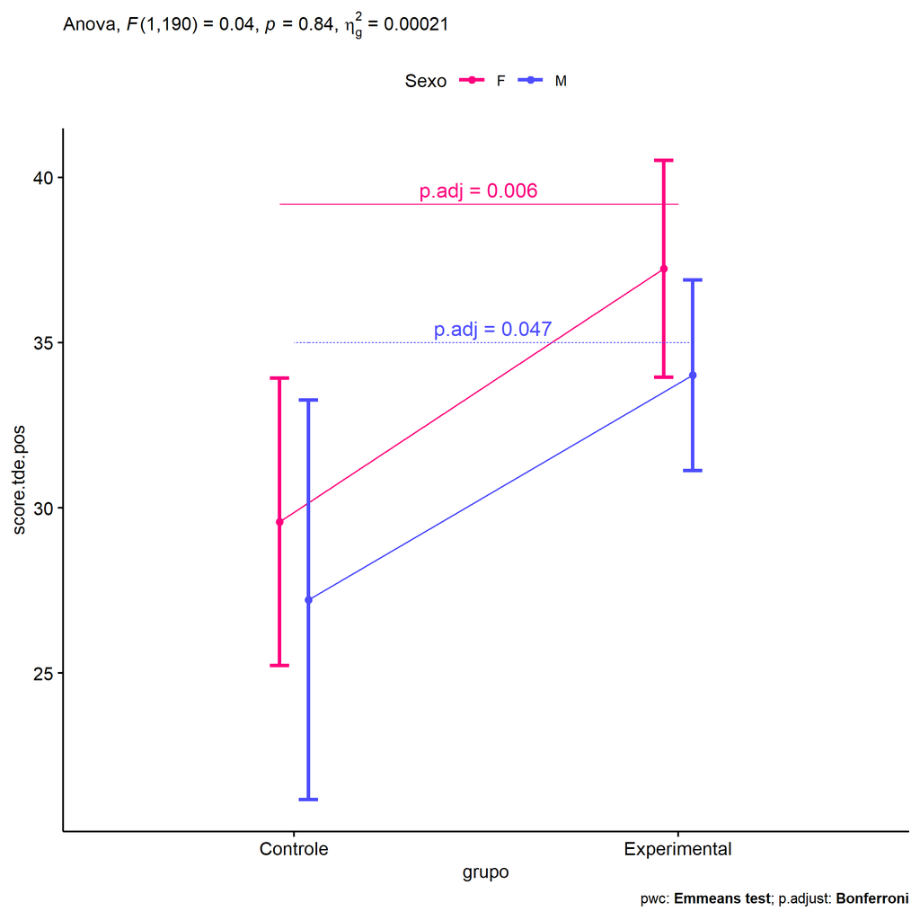

```r
if (!is.null(plots[["grupo"]]))
  plots[["grupo"]] + ggplot2::scale_color_manual(values = color[["Sexo"]])
```

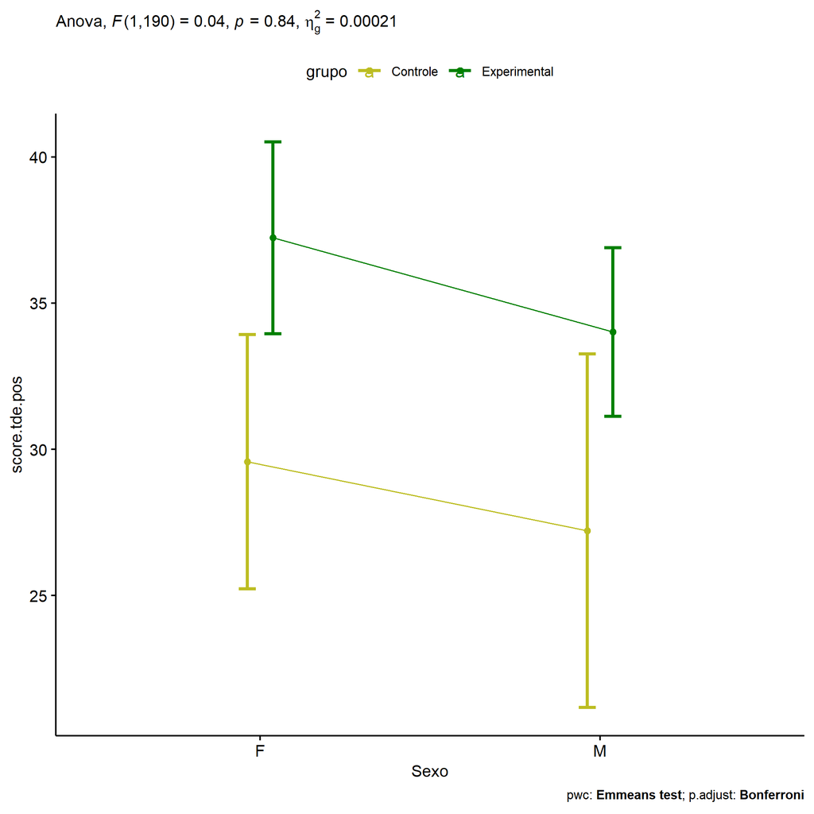

```r
if (!is.null(plots[["Sexo"]]))
  plots[["Sexo"]] + ggplot2::scale_color_manual(values = color[["grupo"]])
```

```r
plots <- twoWayAncovaBoxPlots(
  wdat, "score.tde.pos", c("grupo","Sexo"), aov, pwcs, covar = "score.tde.pre",
  theme = "classic", color = color[["grupo:Sexo"]],
  subtitle = which(aov$Effect == "grupo:Sexo"))
```

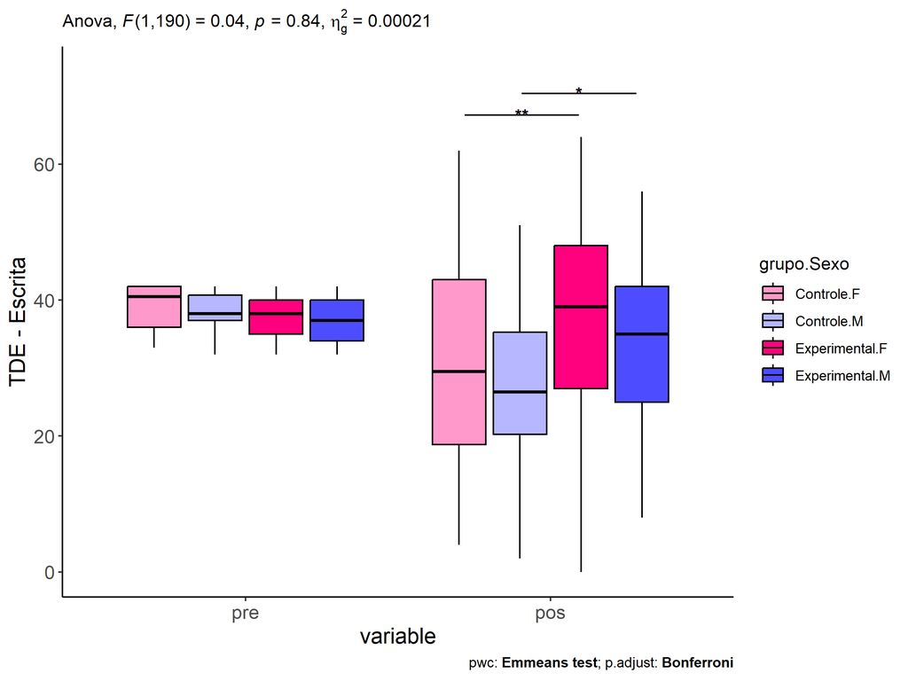

```r
plots[["grupo:Sexo"]] + ggplot2::ylab("TDE - Escrita") + ggplot2::scale_x_discrete(labels=c('pre', 'pos'))
```

```r
plots <- twoWayAncovaBoxPlots(
  wdat.long, "score.tde", c("grupo","Sexo"), aov, pwc.long, pre.post = "time",
  theme = "classic", color = color$prepost)
```

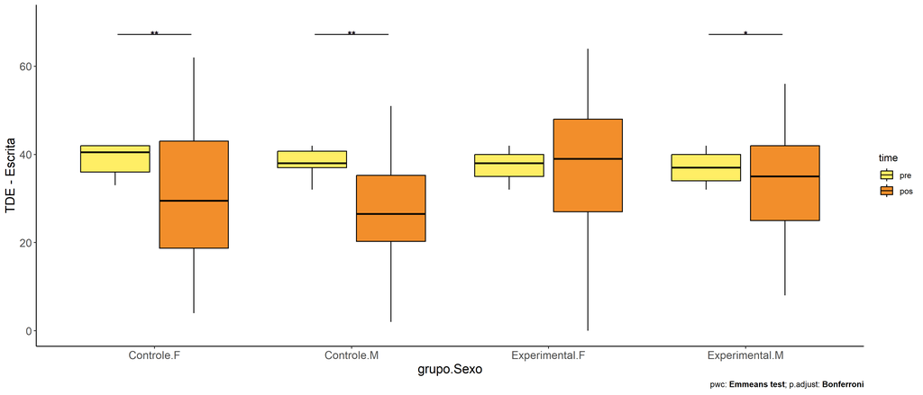

```r
plots[["grupo:Sexo"]] + ggplot2::ylab("TDE - Escrita")
```

### Checking linearity assumption

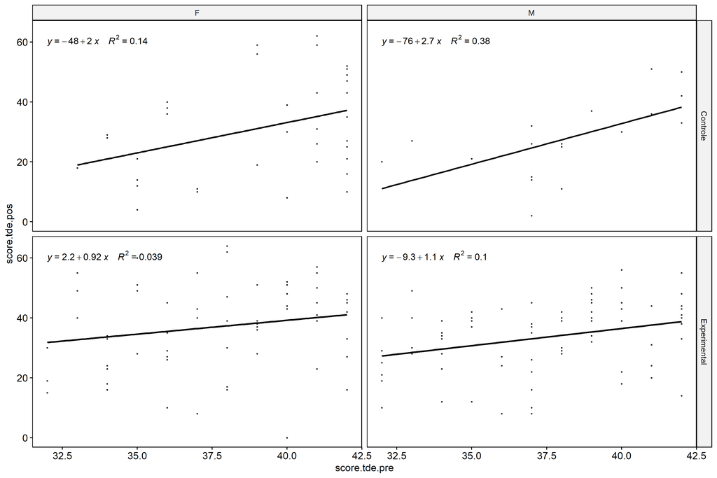

```r
ggscatter(wdat, x = "score.tde.pre", y = "score.tde.pos", size = 0.5,
          facet.by = c("grupo","Sexo"), add = "reg.line")+
  stat_regline_equation(
    aes(label =  paste(..eq.label.., ..rr.label.., sep = "~~~~"))
  )
```

### Checking normality and homogeneity

```r
res <- augment(lm(score.tde.pos ~ score.tde.pre + grupo*Sexo, data = wdat))
```

```r
shapiro_test(res$.resid)
```

```
## # A tibble: 1 × 3
##   variable   statistic p.value
##   <chr>          <dbl>   <dbl>
## 1 res$.resid     0.987  0.0644
```

```r
levene_test(res, .resid ~ grupo*Sexo)
```

```
## # A tibble: 1 × 4
##     df1   df2 statistic      p
##   <int> <int>     <dbl>  <dbl>
## 1     3   191      3.22 0.0239
```

# ANCOVA and Pairwise for two factors **grupo:Zona**

## Without remove non-normal data

```r
pdat = remove_group_data(dat[!is.na(dat[["grupo"]]) & !is.na(dat[["Zona"]]),], "score.tde.pos", c("grupo","Zona"))

pdat.long <- rbind(pdat[,c("id","grupo","Zona")], pdat[,c("id","grupo","Zona")])
pdat.long[["time"]] <- c(rep("pre", nrow(pdat)), rep("pos", nrow(pdat)))
pdat.long[["time"]] <- factor(pdat.long[["time"]], c("pre","pos"))
pdat.long[["score.tde"]] <- c(pdat[["score.tde.pre"]], pdat[["score.tde.pos"]])

aov = anova_test(pdat, score.tde.pos ~ score.tde.pre + grupo*Zona)
laov[["grupo:Zona"]] <- get_anova_table(aov)
```

```r
pwcs <- list()
pwcs[["Zona"]] <- emmeans_test(
  group_by(pdat, grupo), score.tde.pos ~ Zona,
  covariate = score.tde.pre, p.adjust.method = "bonferroni")
pwcs[["grupo"]] <- emmeans_test(
  group_by(pdat, Zona), score.tde.pos ~ grupo,
  covariate = score.tde.pre, p.adjust.method = "bonferroni")

pwc <- plyr::rbind.fill(pwcs[["grupo"]], pwcs[["Zona"]])
pwc <- pwc[,c("grupo","Zona", colnames(pwc)[!colnames(pwc) %in% c("grupo","Zona")])]
```

```r
pwc.long <- emmeans_test(dplyr::group_by_at(pdat.long, c("grupo","Zona")),
                         score.tde ~ time,
                         p.adjust.method = "bonferroni")
lpwc[["grupo:Zona"]] <- plyr::rbind.fill(pwc, pwc.long)
```

```r
ds <- get.descriptives(pdat, "score.tde.pos", c("grupo","Zona"), covar = "score.tde.pre")
ds <- merge(ds[ds$variable != "score.tde.pre",],
            ds[ds$variable == "score.tde.pre", !colnames(ds) %in% c("variable")],
            by = c("grupo","Zona"), all.x = T, suffixes = c("", ".score.tde.pre"))
ds <- merge(get_emmeans(pwcs[["grupo"]]), ds, by = c("grupo","Zona"), suffixes = c(".emms", ""))
ds <- ds[,c("grupo","Zona","n","mean.score.tde.pre","se.score.tde.pre","mean","se","emmean","se.emms")]

colnames(ds) <- c("grupo","Zona", "N", paste0(c("M","SE")," (pre)"),
                  paste0(c("M","SE"), " (unadj)"), paste0(c("M", "SE"), " (adj)"))

lemms[["grupo:Zona"]] <- ds
```

## Computing ANCOVA and PairWise After removing non-normal data (OK)

```r
wdat = pdat

res = residuals(lm(score.tde.pos ~ score.tde.pre + grupo*Zona, data = wdat))
non.normal = getNonNormal(res, wdat$id, plimit = 0.05)

wdat = wdat[!wdat$id %in% non.normal,]

wdat.long <- rbind(wdat[,c("id","grupo","Zona")], wdat[,c("id","grupo","Zona")])
wdat.long[["time"]] <- c(rep("pre", nrow(wdat)), rep("pos", nrow(wdat)))
wdat.long[["time"]] <- factor(wdat.long[["time"]], c("pre","pos"))
wdat.long[["score.tde"]] <- c(wdat[["score.tde.pre"]], wdat[["score.tde.pos"]])


ldat[["grupo:Zona"]] = wdat

(non.normal)
```

```r
aov = anova_test(wdat, score.tde.pos ~ score.tde.pre + grupo*Zona)
laov[["grupo:Zona"]] <- merge(get_anova_table(aov), laov[["grupo:Zona"]], by="Effect", suffixes = c("","'"))

(df = get_anova_table(aov))
```

```
## ANOVA Table (type II tests)
##
##          Effect DFn DFd      F        p p<.05   ges
## 1 score.tde.pre   1 140 19.978 0.000016     * 0.125
## 2         grupo   1 140 13.081 0.000416     * 0.085
## 3          Zona   1 140  6.441 0.012000     * 0.044
## 4    grupo:Zona   1 140  1.558 0.214000       0.011
```

| Effect | DFn | DFd | F | p | p<.05 | ges |
| --- | --- | --- | --- | --- | --- | --- |
| score.tde.pre | 1 | 140 | 19.978 | 0.000 | * | 0.125 |
| grupo | 1 | 140 | 13.081 | 0.000 | * | 0.085 |
| Zona | 1 | 140 | 6.441 | 0.012 | * | 0.044 |
| grupo:Zona | 1 | 140 | 1.558 | 0.214 |  | 0.011 |

```r
pwcs <- list()
pwcs[["Zona"]] <- emmeans_test(
  group_by(wdat, grupo), score.tde.pos ~ Zona,
  covariate = score.tde.pre, p.adjust.method = "bonferroni")
pwcs[["grupo"]] <- emmeans_test(
  group_by(wdat, Zona), score.tde.pos ~ grupo,
  covariate = score.tde.pre, p.adjust.method = "bonferroni")

pwc <- plyr::rbind.fill(pwcs[["grupo"]], pwcs[["Zona"]])
pwc <- pwc[,c("grupo","Zona", colnames(pwc)[!colnames(pwc) %in% c("grupo","Zona")])]
```

| grupo | Zona | term | .y. | group1 | group2 | df | statistic | p | p.adj | p.adj.signif |
| --- | --- | --- | --- | --- | --- | --- | --- | --- | --- | --- |
|  | Rural | score.tde.pre*grupo | score.tde.pos | Controle | Experimental | 140 | -1.793 | 0.075 | 0.075 | ns |
|  | Urbana | score.tde.pre*grupo | score.tde.pos | Controle | Experimental | 140 | -3.312 | 0.001 | 0.001 | ** |
| Controle |  | score.tde.pre*Zona | score.tde.pos | Rural | Urbana | 140 | 2.412 | 0.017 | 0.017 | * |
| Experimental |  | score.tde.pre*Zona | score.tde.pos | Rural | Urbana | 140 | 1.359 | 0.176 | 0.176 | ns |

```r
pwc.long <- emmeans_test(dplyr::group_by_at(wdat.long, c("grupo","Zona")),
                         score.tde ~ time,
                         p.adjust.method = "bonferroni")
lpwc[["grupo:Zona"]] <- merge(plyr::rbind.fill(pwc, pwc.long), lpwc[["grupo:Zona"]], by=c("grupo","Zona","term",".y.","group1","group2"), suffixes = c("","'"))
```

| grupo | Zona | term | .y. | group1 | group2 | df | statistic | p | p.adj | p.adj.signif |
| --- | --- | --- | --- | --- | --- | --- | --- | --- | --- | --- |
| Controle | Rural | time | score.tde | pre | pos | 282 | 2.257 | 0.025 | 0.025 | * |
| Controle | Urbana | time | score.tde | pre | pos | 282 | 5.350 | 0.000 | 0.000 | **** |
| Experimental | Rural | time | score.tde | pre | pos | 282 | 1.334 | 0.183 | 0.183 | ns |
| Experimental | Urbana | time | score.tde | pre | pos | 282 | 2.186 | 0.030 | 0.030 | * |

```r
ds <- get.descriptives(wdat, "score.tde.pos", c("grupo","Zona"), covar = "score.tde.pre")
ds <- merge(ds[ds$variable != "score.tde.pre",],
            ds[ds$variable == "score.tde.pre", !colnames(ds) %in% c("variable")],
            by = c("grupo","Zona"), all.x = T, suffixes = c("", ".score.tde.pre"))
ds <- merge(get_emmeans(pwcs[["grupo"]]), ds, by = c("grupo","Zona"), suffixes = c(".emms", ""))
ds <- ds[,c("grupo","Zona","n","mean.score.tde.pre","se.score.tde.pre","mean","se","emmean","se.emms")]

colnames(ds) <- c("grupo","Zona", "N", paste0(c("M","SE")," (pre)"),
                  paste0(c("M","SE"), " (unadj)"), paste0(c("M", "SE"), " (adj)"))

lemms[["grupo:Zona"]] <- merge(ds, lemms[["grupo:Zona"]], by=c("grupo","Zona"), suffixes = c("","'"))
```

| grupo | Zona | N | M (pre) | SE (pre) | M (unadj) | SE (unadj) | M (adj) | SE (adj) |
| --- | --- | --- | --- | --- | --- | --- | --- | --- |
| Controle | Rural | 23 | 39.522 | 0.625 | 33.261 | 3.016 | 30.588 | 2.609 |
| Controle | Urbana | 18 | 37.500 | 0.628 | 20.722 | 2.572 | 21.188 | 2.873 |
| Experimental | Rural | 64 | 36.719 | 0.380 | 34.500 | 1.608 | 36.179 | 1.568 |
| Experimental | Urbana | 40 | 38.675 | 0.460 | 34.075 | 2.069 | 32.717 | 1.950 |

### Plots for ancova

```r
plots <- twoWayAncovaPlots(
  wdat, "score.tde.pos", c("grupo","Zona"), aov, pwcs, addParam = c("mean_se"),
  font.label.size=10, step.increase=0.05, p.label="p.adj",
  subtitle = which(aov$Effect == "grupo:Zona"))
```

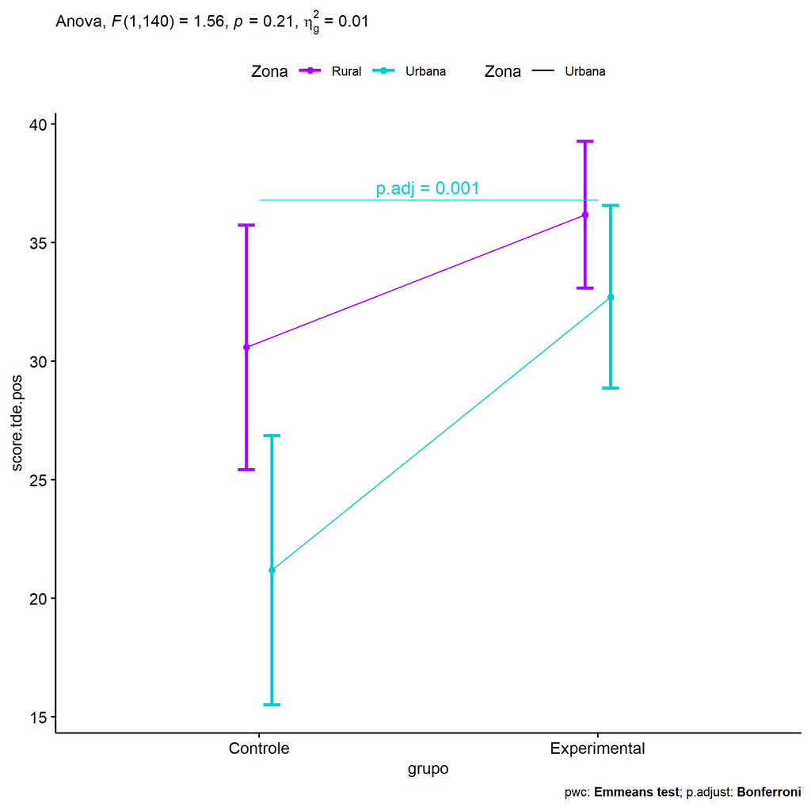

```r
if (!is.null(plots[["grupo"]]))
  plots[["grupo"]] + ggplot2::scale_color_manual(values = color[["Zona"]])
```

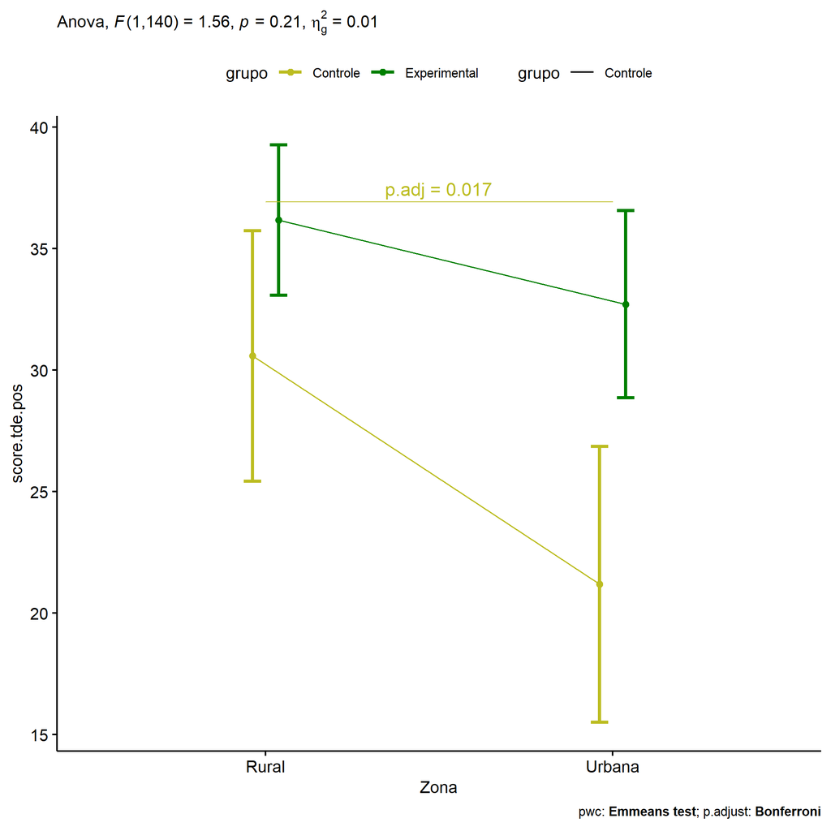

```r
if (!is.null(plots[["Zona"]]))
  plots[["Zona"]] + ggplot2::scale_color_manual(values = color[["grupo"]])
```

```r
plots <- twoWayAncovaBoxPlots(
  wdat, "score.tde.pos", c("grupo","Zona"), aov, pwcs, covar = "score.tde.pre",
  theme = "classic", color = color[["grupo:Zona"]],
  subtitle = which(aov$Effect == "grupo:Zona"))
```

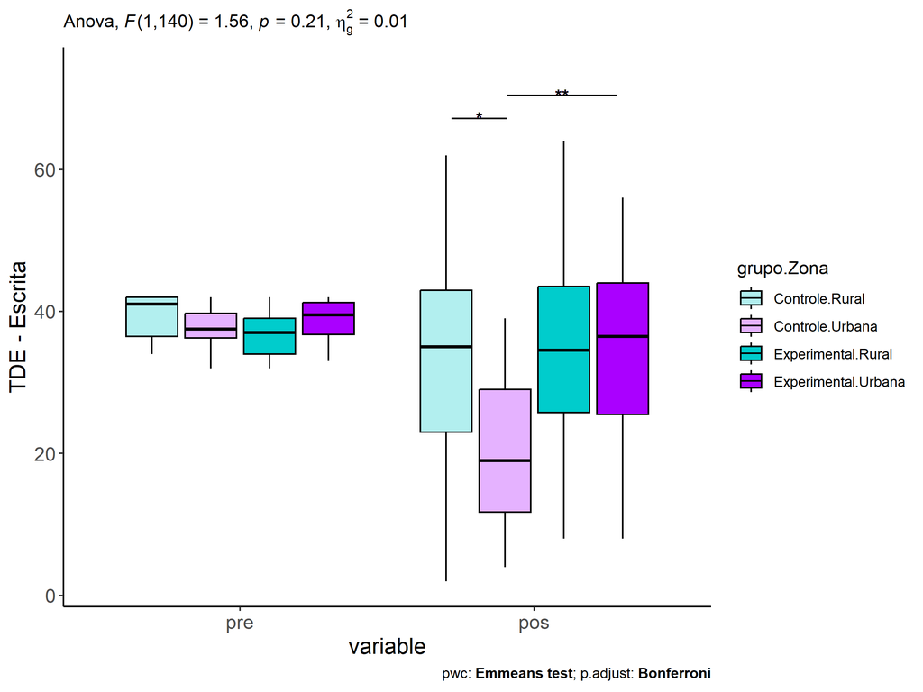

```r
plots[["grupo:Zona"]] + ggplot2::ylab("TDE - Escrita") + ggplot2::scale_x_discrete(labels=c('pre', 'pos'))
```

```r
plots <- twoWayAncovaBoxPlots(
  wdat.long, "score.tde", c("grupo","Zona"), aov, pwc.long, pre.post = "time",
  theme = "classic", color = color$prepost)
```

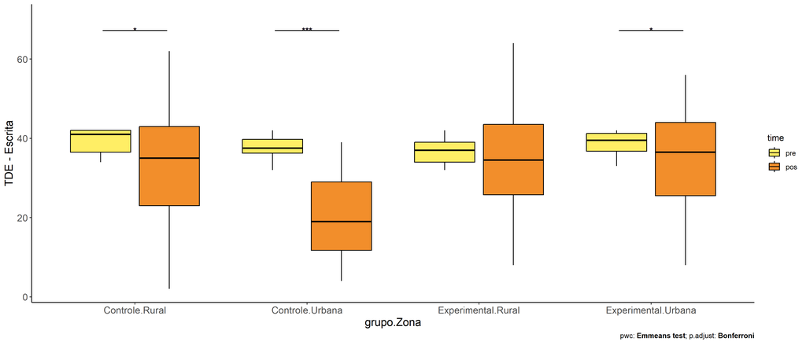

```r
plots[["grupo:Zona"]] + ggplot2::ylab("TDE - Escrita")
```

### Checking linearity assumption

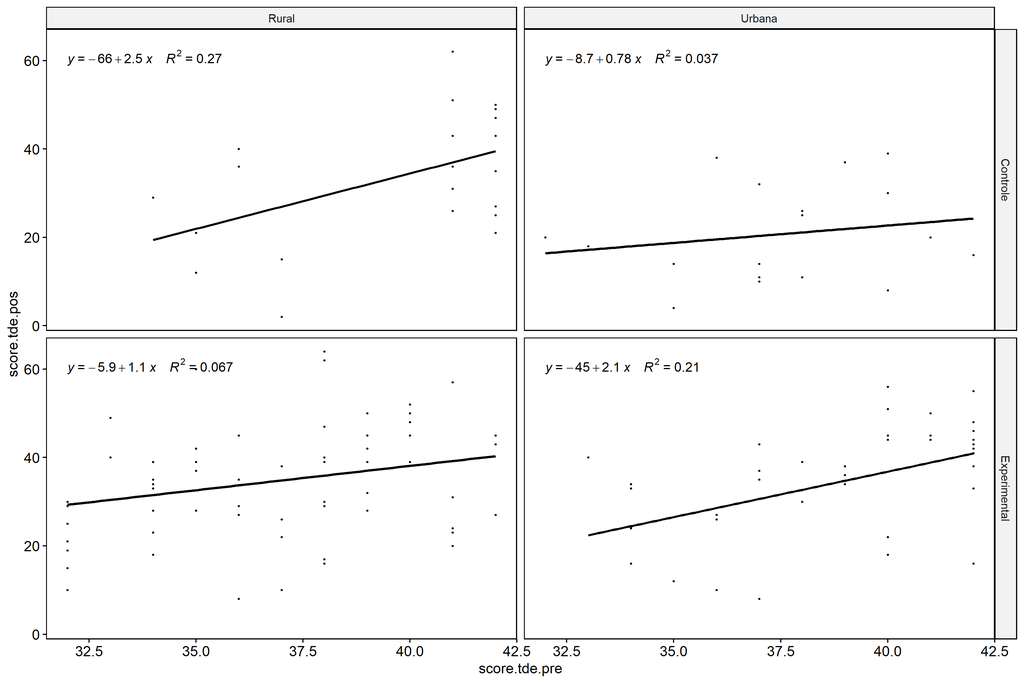

```r
ggscatter(wdat, x = "score.tde.pre", y = "score.tde.pos", size = 0.5,
          facet.by = c("grupo","Zona"), add = "reg.line")+
  stat_regline_equation(
    aes(label =  paste(..eq.label.., ..rr.label.., sep = "~~~~"))
  )
```

### Checking normality and homogeneity

```r
res <- augment(lm(score.tde.pos ~ score.tde.pre + grupo*Zona, data = wdat))
```

```r
shapiro_test(res$.resid)
```

```
## # A tibble: 1 × 3
##   variable   statistic p.value
##   <chr>          <dbl>   <dbl>
## 1 res$.resid     0.987   0.207
```

```r
levene_test(res, .resid ~ grupo*Zona)
```

```
## # A tibble: 1 × 4
##     df1   df2 statistic     p
##   <int> <int>     <dbl> <dbl>
## 1     3   141     0.226 0.878
```

# ANCOVA and Pairwise for two factors **grupo:Cor.Raca**

## Without remove non-normal data

```r
pdat = remove_group_data(dat[!is.na(dat[["grupo"]]) & !is.na(dat[["Cor.Raca"]]),], "score.tde.pos", c("grupo","Cor.Raca"))

pdat.long <- rbind(pdat[,c("id","grupo","Cor.Raca")], pdat[,c("id","grupo","Cor.Raca")])
pdat.long[["time"]] <- c(rep("pre", nrow(pdat)), rep("pos", nrow(pdat)))
pdat.long[["time"]] <- factor(pdat.long[["time"]], c("pre","pos"))
pdat.long[["score.tde"]] <- c(pdat[["score.tde.pre"]], pdat[["score.tde.pos"]])

aov = anova_test(pdat, score.tde.pos ~ score.tde.pre + grupo*Cor.Raca)
laov[["grupo:Cor.Raca"]] <- get_anova_table(aov)
```

```r
pwcs <- list()
pwcs[["Cor.Raca"]] <- emmeans_test(
  group_by(pdat, grupo), score.tde.pos ~ Cor.Raca,
  covariate = score.tde.pre, p.adjust.method = "bonferroni")
pwcs[["grupo"]] <- emmeans_test(
  group_by(pdat, Cor.Raca), score.tde.pos ~ grupo,
  covariate = score.tde.pre, p.adjust.method = "bonferroni")

pwc <- plyr::rbind.fill(pwcs[["grupo"]], pwcs[["Cor.Raca"]])
pwc <- pwc[,c("grupo","Cor.Raca", colnames(pwc)[!colnames(pwc) %in% c("grupo","Cor.Raca")])]
```

```r
pwc.long <- emmeans_test(dplyr::group_by_at(pdat.long, c("grupo","Cor.Raca")),
                         score.tde ~ time,
                         p.adjust.method = "bonferroni")
lpwc[["grupo:Cor.Raca"]] <- plyr::rbind.fill(pwc, pwc.long)
```

```r
ds <- get.descriptives(pdat, "score.tde.pos", c("grupo","Cor.Raca"), covar = "score.tde.pre")
ds <- merge(ds[ds$variable != "score.tde.pre",],
            ds[ds$variable == "score.tde.pre", !colnames(ds) %in% c("variable")],
            by = c("grupo","Cor.Raca"), all.x = T, suffixes = c("", ".score.tde.pre"))
ds <- merge(get_emmeans(pwcs[["grupo"]]), ds, by = c("grupo","Cor.Raca"), suffixes = c(".emms", ""))
ds <- ds[,c("grupo","Cor.Raca","n","mean.score.tde.pre","se.score.tde.pre","mean","se","emmean","se.emms")]

colnames(ds) <- c("grupo","Cor.Raca", "N", paste0(c("M","SE")," (pre)"),
                  paste0(c("M","SE"), " (unadj)"), paste0(c("M", "SE"), " (adj)"))

lemms[["grupo:Cor.Raca"]] <- ds
```

## Computing ANCOVA and PairWise After removing non-normal data (OK)

```r
wdat = pdat

res = residuals(lm(score.tde.pos ~ score.tde.pre + grupo*Cor.Raca, data = wdat))
non.normal = getNonNormal(res, wdat$id, plimit = 0.05)

wdat = wdat[!wdat$id %in% non.normal,]

wdat.long <- rbind(wdat[,c("id","grupo","Cor.Raca")], wdat[,c("id","grupo","Cor.Raca")])
wdat.long[["time"]] <- c(rep("pre", nrow(wdat)), rep("pos", nrow(wdat)))
wdat.long[["time"]] <- factor(wdat.long[["time"]], c("pre","pos"))
wdat.long[["score.tde"]] <- c(wdat[["score.tde.pre"]], wdat[["score.tde.pos"]])


ldat[["grupo:Cor.Raca"]] = wdat

(non.normal)
```

```r
aov = anova_test(wdat, score.tde.pos ~ score.tde.pre + grupo*Cor.Raca)
laov[["grupo:Cor.Raca"]] <- merge(get_anova_table(aov), laov[["grupo:Cor.Raca"]], by="Effect", suffixes = c("","'"))

(df = get_anova_table(aov))
```

```
## ANOVA Table (type II tests)
##
##           Effect DFn DFd     F     p p<.05   ges
## 1  score.tde.pre   1  72 8.902 0.004     * 0.110
## 2          grupo   1  72 5.205 0.025     * 0.067
## 3       Cor.Raca   1  72 0.220 0.641       0.003
## 4 grupo:Cor.Raca   1  72 0.460 0.500       0.006
```

| Effect | DFn | DFd | F | p | p<.05 | ges |
| --- | --- | --- | --- | --- | --- | --- |
| score.tde.pre | 1 | 72 | 8.902 | 0.004 | * | 0.110 |
| grupo | 1 | 72 | 5.205 | 0.025 | * | 0.067 |
| Cor.Raca | 1 | 72 | 0.220 | 0.641 |  | 0.003 |
| grupo:Cor.Raca | 1 | 72 | 0.460 | 0.500 |  | 0.006 |

```r
pwcs <- list()
pwcs[["Cor.Raca"]] <- emmeans_test(
  group_by(wdat, grupo), score.tde.pos ~ Cor.Raca,
  covariate = score.tde.pre, p.adjust.method = "bonferroni")
pwcs[["grupo"]] <- emmeans_test(
  group_by(wdat, Cor.Raca), score.tde.pos ~ grupo,
  covariate = score.tde.pre, p.adjust.method = "bonferroni")

pwc <- plyr::rbind.fill(pwcs[["grupo"]], pwcs[["Cor.Raca"]])
pwc <- pwc[,c("grupo","Cor.Raca", colnames(pwc)[!colnames(pwc) %in% c("grupo","Cor.Raca")])]
```

| grupo | Cor.Raca | term | .y. | group1 | group2 | df | statistic | p | p.adj | p.adj.signif |
| --- | --- | --- | --- | --- | --- | --- | --- | --- | --- | --- |
|  | Branca | score.tde.pre*grupo | score.tde.pos | Controle | Experimental | 72 | -1.743 | 0.086 | 0.086 | ns |
|  | Parda | score.tde.pre*grupo | score.tde.pos | Controle | Experimental | 72 | -1.632 | 0.107 | 0.107 | ns |
| Controle |  | score.tde.pre*Cor.Raca | score.tde.pos | Branca | Parda | 72 | -0.302 | 0.763 | 0.763 | ns |
| Experimental |  | score.tde.pre*Cor.Raca | score.tde.pos | Branca | Parda | 72 | 0.769 | 0.444 | 0.444 | ns |

```r
pwc.long <- emmeans_test(dplyr::group_by_at(wdat.long, c("grupo","Cor.Raca")),
                         score.tde ~ time,
                         p.adjust.method = "bonferroni")
lpwc[["grupo:Cor.Raca"]] <- merge(plyr::rbind.fill(pwc, pwc.long), lpwc[["grupo:Cor.Raca"]], by=c("grupo","Cor.Raca","term",".y.","group1","group2"), suffixes = c("","'"))
```

| grupo | Cor.Raca | term | .y. | group1 | group2 | df | statistic | p | p.adj | p.adj.signif |
| --- | --- | --- | --- | --- | --- | --- | --- | --- | --- | --- |
| Controle | Branca | time | score.tde | pre | pos | 146 | 1.921 | 0.057 | 0.057 | ns |
| Controle | Parda | time | score.tde | pre | pos | 146 | 2.876 | 0.005 | 0.005 | ** |
| Experimental | Branca | time | score.tde | pre | pos | 146 | 0.049 | 0.961 | 0.961 | ns |
| Experimental | Parda | time | score.tde | pre | pos | 146 | 1.571 | 0.118 | 0.118 | ns |

```r
ds <- get.descriptives(wdat, "score.tde.pos", c("grupo","Cor.Raca"), covar = "score.tde.pre")
ds <- merge(ds[ds$variable != "score.tde.pre",],
            ds[ds$variable == "score.tde.pre", !colnames(ds) %in% c("variable")],
            by = c("grupo","Cor.Raca"), all.x = T, suffixes = c("", ".score.tde.pre"))
ds <- merge(get_emmeans(pwcs[["grupo"]]), ds, by = c("grupo","Cor.Raca"), suffixes = c(".emms", ""))
ds <- ds[,c("grupo","Cor.Raca","n","mean.score.tde.pre","se.score.tde.pre","mean","se","emmean","se.emms")]

colnames(ds) <- c("grupo","Cor.Raca", "N", paste0(c("M","SE")," (pre)"),
                  paste0(c("M","SE"), " (unadj)"), paste0(c("M", "SE"), " (adj)"))

lemms[["grupo:Cor.Raca"]] <- merge(ds, lemms[["grupo:Cor.Raca"]], by=c("grupo","Cor.Raca"), suffixes = c("","'"))
```

| grupo | Cor.Raca | N | M (pre) | SE (pre) | M (unadj) | SE (unadj) | M (adj) | SE (adj) |
| --- | --- | --- | --- | --- | --- | --- | --- | --- |
| Controle | Branca | 6 | 38.167 | 1.167 | 25.667 | 6.200 | 25.218 | 6.074 |
| Controle | Parda | 22 | 39.045 | 0.646 | 29.273 | 3.915 | 27.295 | 3.239 |
| Experimental | Branca | 15 | 37.867 | 0.810 | 37.667 | 3.696 | 37.741 | 3.840 |
| Experimental | Parda | 34 | 37.147 | 0.498 | 32.853 | 2.460 | 34.179 | 2.589 |

### Plots for ancova

```r
plots <- twoWayAncovaPlots(
  wdat, "score.tde.pos", c("grupo","Cor.Raca"), aov, pwcs, addParam = c("mean_se"),
  font.label.size=10, step.increase=0.05, p.label="p.adj",
  subtitle = which(aov$Effect == "grupo:Cor.Raca"))
```

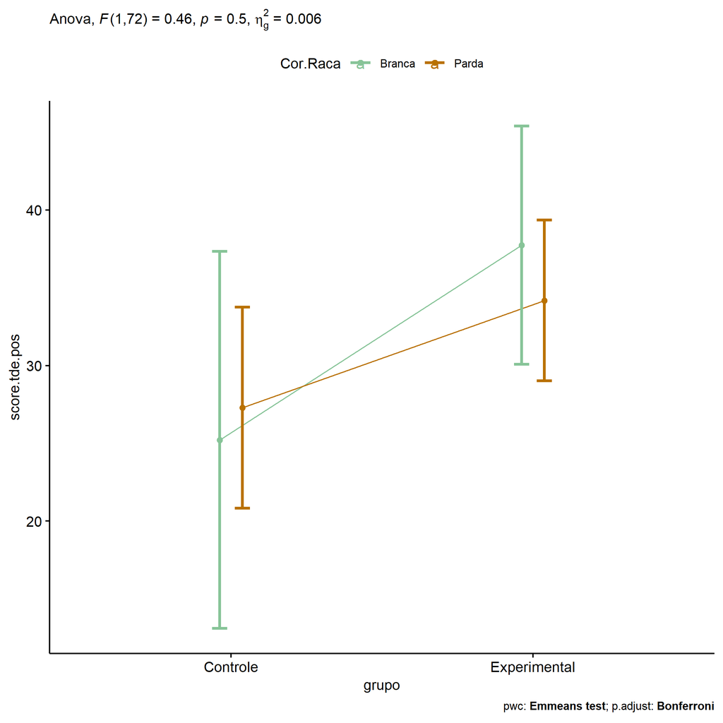

```r
if (!is.null(plots[["grupo"]]))
  plots[["grupo"]] + ggplot2::scale_color_manual(values = color[["Cor.Raca"]])
```

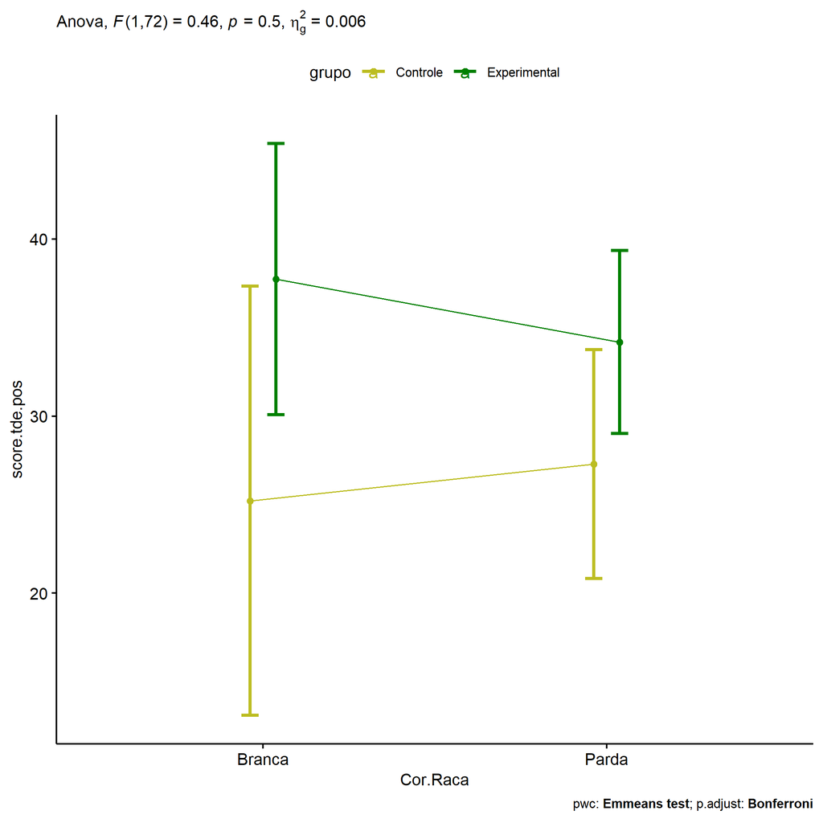

```r
if (!is.null(plots[["Cor.Raca"]]))
  plots[["Cor.Raca"]] + ggplot2::scale_color_manual(values = color[["grupo"]])
```

```r
plots <- twoWayAncovaBoxPlots(
  wdat, "score.tde.pos", c("grupo","Cor.Raca"), aov, pwcs, covar = "score.tde.pre",
  theme = "classic", color = color[["grupo:Cor.Raca"]],
  subtitle = which(aov$Effect == "grupo:Cor.Raca"))
```

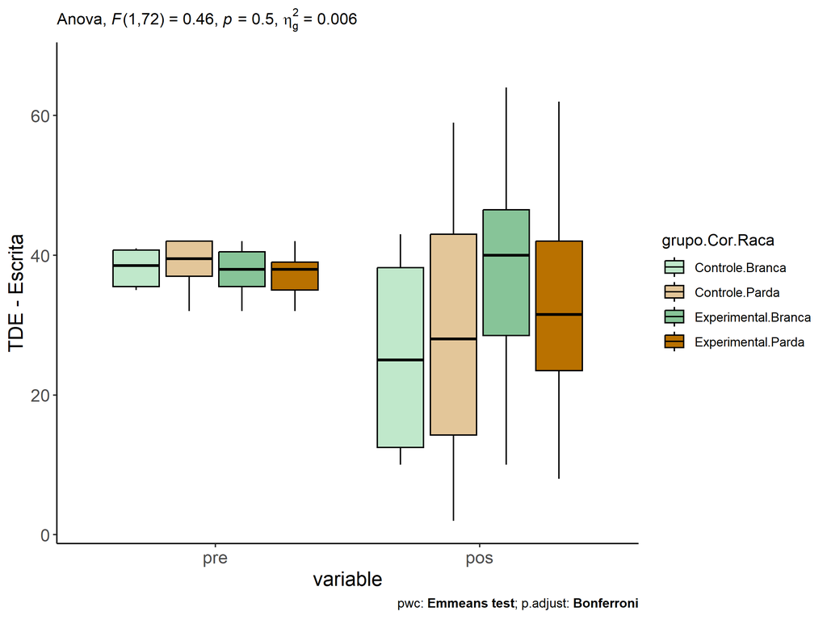

```r
plots[["grupo:Cor.Raca"]] + ggplot2::ylab("TDE - Escrita") + ggplot2::scale_x_discrete(labels=c('pre', 'pos'))
```

```r
plots <- twoWayAncovaBoxPlots(
  wdat.long, "score.tde", c("grupo","Cor.Raca"), aov, pwc.long, pre.post = "time",
  theme = "classic", color = color$prepost)
```

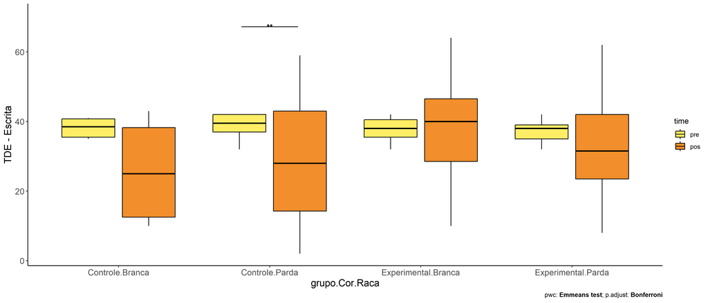

```r
plots[["grupo:Cor.Raca"]] + ggplot2::ylab("TDE - Escrita")
```

### Checking linearity assumption

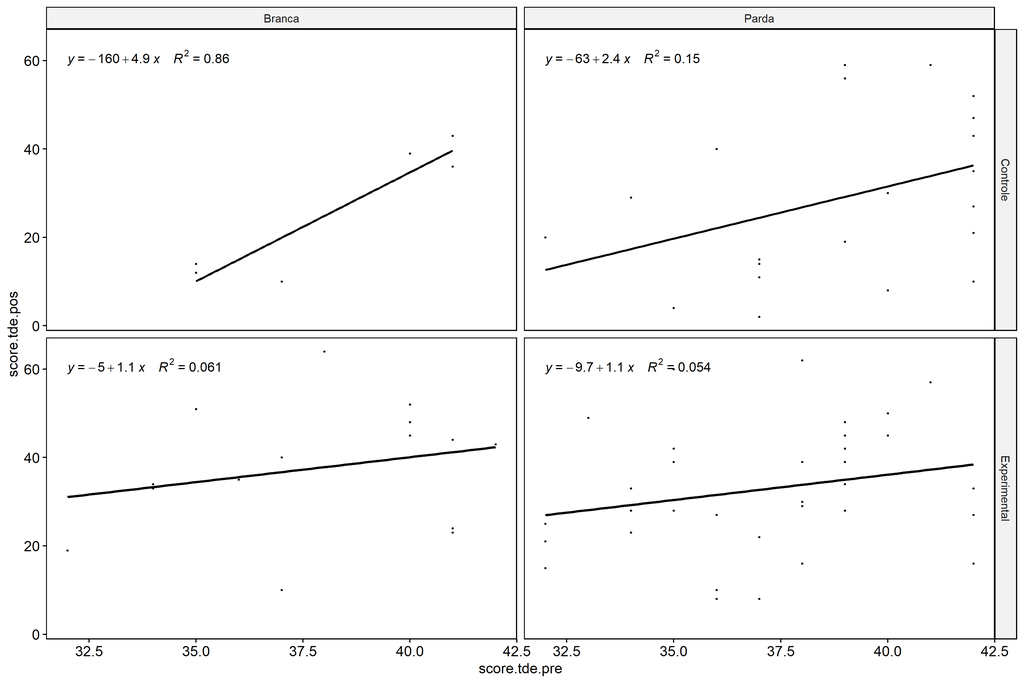

```r
ggscatter(wdat, x = "score.tde.pre", y = "score.tde.pos", size = 0.5,
          facet.by = c("grupo","Cor.Raca"), add = "reg.line")+
  stat_regline_equation(
    aes(label =  paste(..eq.label.., ..rr.label.., sep = "~~~~"))
  )
```

### Checking normality and homogeneity

```r
res <- augment(lm(score.tde.pos ~ score.tde.pre + grupo*Cor.Raca, data = wdat))
```

```r
shapiro_test(res$.resid)
```

```
## # A tibble: 1 × 3
##   variable   statistic p.value
##   <chr>          <dbl>   <dbl>
## 1 res$.resid     0.978   0.204
```

```r
levene_test(res, .resid ~ grupo*Cor.Raca)
```

```
## # A tibble: 1 × 4
##     df1   df2 statistic     p
##   <int> <int>     <dbl> <dbl>
## 1     3    73      1.21 0.312
```

# ANCOVA and Pairwise for two factors **grupo:Serie**

## Without remove non-normal data

```r
pdat = remove_group_data(dat[!is.na(dat[["grupo"]]) & !is.na(dat[["Serie"]]),], "score.tde.pos", c("grupo","Serie"))

pdat.long <- rbind(pdat[,c("id","grupo","Serie")], pdat[,c("id","grupo","Serie")])
pdat.long[["time"]] <- c(rep("pre", nrow(pdat)), rep("pos", nrow(pdat)))
pdat.long[["time"]] <- factor(pdat.long[["time"]], c("pre","pos"))
pdat.long[["score.tde"]] <- c(pdat[["score.tde.pre"]], pdat[["score.tde.pos"]])

aov = anova_test(pdat, score.tde.pos ~ score.tde.pre + grupo*Serie)
laov[["grupo:Serie"]] <- get_anova_table(aov)
```

```r
pwcs <- list()
pwcs[["Serie"]] <- emmeans_test(
  group_by(pdat, grupo), score.tde.pos ~ Serie,
  covariate = score.tde.pre, p.adjust.method = "bonferroni")
pwcs[["grupo"]] <- emmeans_test(
  group_by(pdat, Serie), score.tde.pos ~ grupo,
  covariate = score.tde.pre, p.adjust.method = "bonferroni")

pwc <- plyr::rbind.fill(pwcs[["grupo"]], pwcs[["Serie"]])
pwc <- pwc[,c("grupo","Serie", colnames(pwc)[!colnames(pwc) %in% c("grupo","Serie")])]
```

```r
pwc.long <- emmeans_test(dplyr::group_by_at(pdat.long, c("grupo","Serie")),
                         score.tde ~ time,
                         p.adjust.method = "bonferroni")
lpwc[["grupo:Serie"]] <- plyr::rbind.fill(pwc, pwc.long)
```

```r
ds <- get.descriptives(pdat, "score.tde.pos", c("grupo","Serie"), covar = "score.tde.pre")
ds <- merge(ds[ds$variable != "score.tde.pre",],
            ds[ds$variable == "score.tde.pre", !colnames(ds) %in% c("variable")],
            by = c("grupo","Serie"), all.x = T, suffixes = c("", ".score.tde.pre"))
ds <- merge(get_emmeans(pwcs[["grupo"]]), ds, by = c("grupo","Serie"), suffixes = c(".emms", ""))
ds <- ds[,c("grupo","Serie","n","mean.score.tde.pre","se.score.tde.pre","mean","se","emmean","se.emms")]

colnames(ds) <- c("grupo","Serie", "N", paste0(c("M","SE")," (pre)"),
                  paste0(c("M","SE"), " (unadj)"), paste0(c("M", "SE"), " (adj)"))

lemms[["grupo:Serie"]] <- ds
```

## Computing ANCOVA and PairWise After removing non-normal data (OK)

```r
wdat = pdat

res = residuals(lm(score.tde.pos ~ score.tde.pre + grupo*Serie, data = wdat))
non.normal = getNonNormal(res, wdat$id, plimit = 0.05)

wdat = wdat[!wdat$id %in% non.normal,]

wdat.long <- rbind(wdat[,c("id","grupo","Serie")], wdat[,c("id","grupo","Serie")])
wdat.long[["time"]] <- c(rep("pre", nrow(wdat)), rep("pos", nrow(wdat)))
wdat.long[["time"]] <- factor(wdat.long[["time"]], c("pre","pos"))
wdat.long[["score.tde"]] <- c(wdat[["score.tde.pre"]], wdat[["score.tde.pos"]])


ldat[["grupo:Serie"]] = wdat

(non.normal)
```

```r
aov = anova_test(wdat, score.tde.pos ~ score.tde.pre + grupo*Serie)
laov[["grupo:Serie"]] <- merge(get_anova_table(aov), laov[["grupo:Serie"]], by="Effect", suffixes = c("","'"))

(df = get_anova_table(aov))
```

```
## ANOVA Table (type II tests)
##
##          Effect DFn DFd      F        p p<.05   ges
## 1 score.tde.pre   1 186 18.374 2.91e-05     * 0.090
## 2         grupo   1 186 15.837 9.88e-05     * 0.078
## 3         Serie   3 186 12.849 1.15e-07     * 0.172
## 4   grupo:Serie   3 186  1.102 3.49e-01       0.017
```

| Effect | DFn | DFd | F | p | p<.05 | ges |
| --- | --- | --- | --- | --- | --- | --- |
| score.tde.pre | 1 | 186 | 18.374 | 0.000 | * | 0.090 |
| grupo | 1 | 186 | 15.837 | 0.000 | * | 0.078 |
| Serie | 3 | 186 | 12.849 | 0.000 | * | 0.172 |
| grupo:Serie | 3 | 186 | 1.102 | 0.349 |  | 0.017 |

```r
pwcs <- list()
pwcs[["Serie"]] <- emmeans_test(
  group_by(wdat, grupo), score.tde.pos ~ Serie,
  covariate = score.tde.pre, p.adjust.method = "bonferroni")
pwcs[["grupo"]] <- emmeans_test(
  group_by(wdat, Serie), score.tde.pos ~ grupo,
  covariate = score.tde.pre, p.adjust.method = "bonferroni")

pwc <- plyr::rbind.fill(pwcs[["grupo"]], pwcs[["Serie"]])
pwc <- pwc[,c("grupo","Serie", colnames(pwc)[!colnames(pwc) %in% c("grupo","Serie")])]
```

| grupo | Serie | term | .y. | group1 | group2 | df | statistic | p | p.adj | p.adj.signif |
| --- | --- | --- | --- | --- | --- | --- | --- | --- | --- | --- |
|  | 6 ano | score.tde.pre*grupo | score.tde.pos | Controle | Experimental | 186 | -1.180 | 0.240 | 0.240 | ns |
|  | 7 ano | score.tde.pre*grupo | score.tde.pos | Controle | Experimental | 186 | -3.368 | 0.001 | 0.001 | *** |
|  | 8 ano | score.tde.pre*grupo | score.tde.pos | Controle | Experimental | 186 | -2.556 | 0.011 | 0.011 | * |
|  | 9 ano | score.tde.pre*grupo | score.tde.pos | Controle | Experimental | 186 | -0.547 | 0.585 | 0.585 | ns |
| Controle |  | score.tde.pre*Serie | score.tde.pos | 6 ano | 7 ano | 186 | 0.546 | 0.586 | 1.000 | ns |
| Controle |  | score.tde.pre*Serie | score.tde.pos | 6 ano | 8 ano | 186 | -2.347 | 0.020 | 0.120 | ns |
| Controle |  | score.tde.pre*Serie | score.tde.pos | 6 ano | 9 ano | 186 | -2.056 | 0.041 | 0.247 | ns |
| Controle |  | score.tde.pre*Serie | score.tde.pos | 7 ano | 8 ano | 186 | -3.103 | 0.002 | 0.013 | * |
| Controle |  | score.tde.pre*Serie | score.tde.pos | 7 ano | 9 ano | 186 | -2.581 | 0.011 | 0.064 | ns |
| Controle |  | score.tde.pre*Serie | score.tde.pos | 8 ano | 9 ano | 186 | -0.228 | 0.820 | 1.000 | ns |
| Experimental |  | score.tde.pre*Serie | score.tde.pos | 6 ano | 7 ano | 186 | -1.794 | 0.074 | 0.446 | ns |
| Experimental |  | score.tde.pre*Serie | score.tde.pos | 6 ano | 8 ano | 186 | -4.890 | 0.000 | 0.000 | **** |
| Experimental |  | score.tde.pre*Serie | score.tde.pos | 6 ano | 9 ano | 186 | -3.490 | 0.001 | 0.004 | ** |
| Experimental |  | score.tde.pre*Serie | score.tde.pos | 7 ano | 8 ano | 186 | -3.562 | 0.000 | 0.003 | ** |
| Experimental |  | score.tde.pre*Serie | score.tde.pos | 7 ano | 9 ano | 186 | -1.913 | 0.057 | 0.344 | ns |
| Experimental |  | score.tde.pre*Serie | score.tde.pos | 8 ano | 9 ano | 186 | 1.807 | 0.072 | 0.434 | ns |

```r
pwc.long <- emmeans_test(dplyr::group_by_at(wdat.long, c("grupo","Serie")),
                         score.tde ~ time,
                         p.adjust.method = "bonferroni")
lpwc[["grupo:Serie"]] <- merge(plyr::rbind.fill(pwc, pwc.long), lpwc[["grupo:Serie"]], by=c("grupo","Serie","term",".y.","group1","group2"), suffixes = c("","'"))
```

| grupo | Serie | term | .y. | group1 | group2 | df | statistic | p | p.adj | p.adj.signif |
| --- | --- | --- | --- | --- | --- | --- | --- | --- | --- | --- |
| Controle | 6 ano | time | score.tde | pre | pos | 374 | 3.535 | 0.000 | 0.000 | *** |
| Controle | 7 ano | time | score.tde | pre | pos | 374 | 4.863 | 0.000 | 0.000 | **** |
| Controle | 8 ano | time | score.tde | pre | pos | 374 | 0.735 | 0.463 | 0.463 | ns |
| Controle | 9 ano | time | score.tde | pre | pos | 374 | 0.147 | 0.883 | 0.883 | ns |
| Experimental | 6 ano | time | score.tde | pre | pos | 374 | 4.314 | 0.000 | 0.000 | **** |
| Experimental | 7 ano | time | score.tde | pre | pos | 374 | 2.108 | 0.036 | 0.036 | * |
| Experimental | 8 ano | time | score.tde | pre | pos | 374 | -2.585 | 0.010 | 0.010 | * |
| Experimental | 9 ano | time | score.tde | pre | pos | 374 | -0.701 | 0.484 | 0.484 | ns |

```r
ds <- get.descriptives(wdat, "score.tde.pos", c("grupo","Serie"), covar = "score.tde.pre")
ds <- merge(ds[ds$variable != "score.tde.pre",],
            ds[ds$variable == "score.tde.pre", !colnames(ds) %in% c("variable")],
            by = c("grupo","Serie"), all.x = T, suffixes = c("", ".score.tde.pre"))
ds <- merge(get_emmeans(pwcs[["grupo"]]), ds, by = c("grupo","Serie"), suffixes = c(".emms", ""))
ds <- ds[,c("grupo","Serie","n","mean.score.tde.pre","se.score.tde.pre","mean","se","emmean","se.emms")]

colnames(ds) <- c("grupo","Serie", "N", paste0(c("M","SE")," (pre)"),
                  paste0(c("M","SE"), " (unadj)"), paste0(c("M", "SE"), " (adj)"))

lemms[["grupo:Serie"]] <- merge(ds, lemms[["grupo:Serie"]], by=c("grupo","Serie"), suffixes = c("","'"))
```

| grupo | Serie | N | M (pre) | SE (pre) | M (unadj) | SE (unadj) | M (adj) | SE (adj) |
| --- | --- | --- | --- | --- | --- | --- | --- | --- |
| Controle | 6 ano | 13 | 38.846 | 0.775 | 26.231 | 3.669 | 24.951 | 3.326 |
| Controle | 7 ano | 17 | 38.059 | 0.847 | 22.882 | 4.172 | 22.547 | 2.897 |
| Controle | 8 ano | 17 | 38.824 | 0.682 | 36.529 | 2.922 | 35.276 | 2.911 |
| Controle | 9 ano | 7 | 40.571 | 0.869 | 39.857 | 4.361 | 36.506 | 4.581 |
| Experimental | 6 ano | 43 | 37.116 | 0.467 | 28.651 | 1.830 | 29.447 | 1.831 |
| Experimental | 7 ano | 47 | 37.043 | 0.475 | 33.085 | 1.712 | 33.970 | 1.754 |
| Experimental | 8 ano | 19 | 37.158 | 0.663 | 44.789 | 2.246 | 45.535 | 2.745 |
| Experimental | 9 ano | 32 | 38.375 | 0.585 | 39.969 | 2.263 | 39.254 | 2.118 |

### Plots for ancova

```r
plots <- twoWayAncovaPlots(
  wdat, "score.tde.pos", c("grupo","Serie"), aov, pwcs, addParam = c("mean_se"),
  font.label.size=10, step.increase=0.05, p.label="p.adj",
  subtitle = which(aov$Effect == "grupo:Serie"))
```

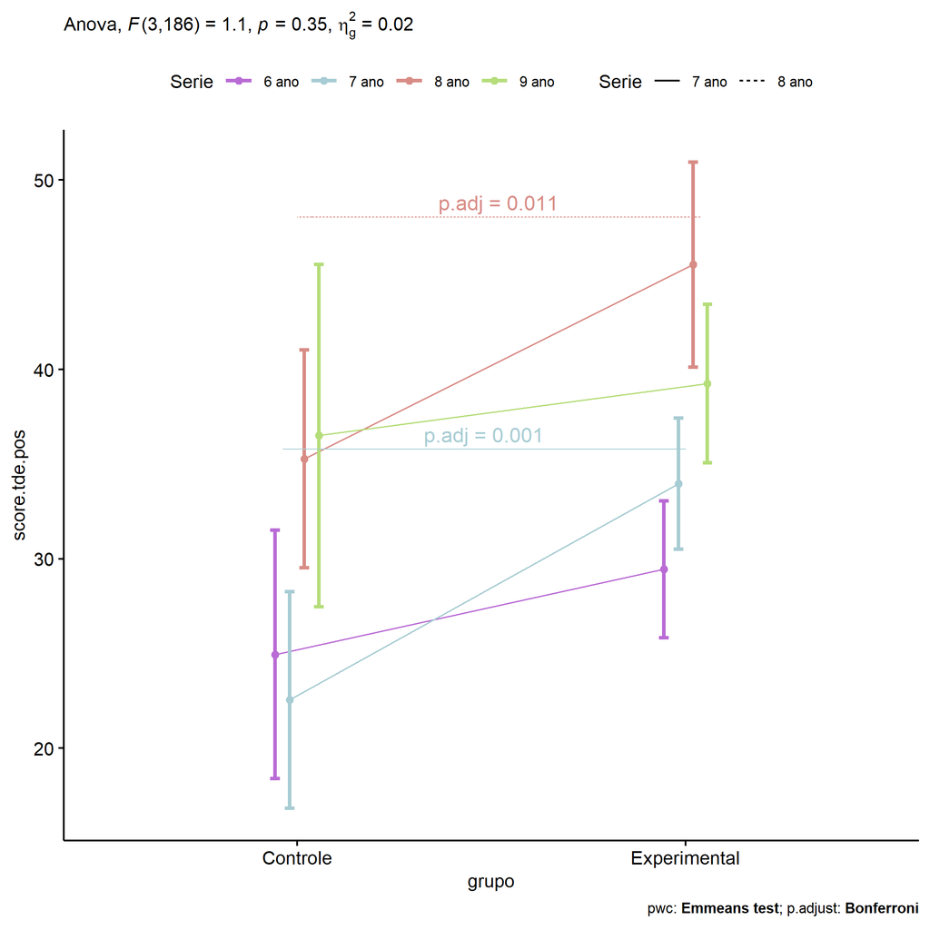

```r
if (!is.null(plots[["grupo"]]))
  plots[["grupo"]] + ggplot2::scale_color_manual(values = color[["Serie"]])
```

```
## Warning: `position_dodge()` requires non-overlapping x intervals
```

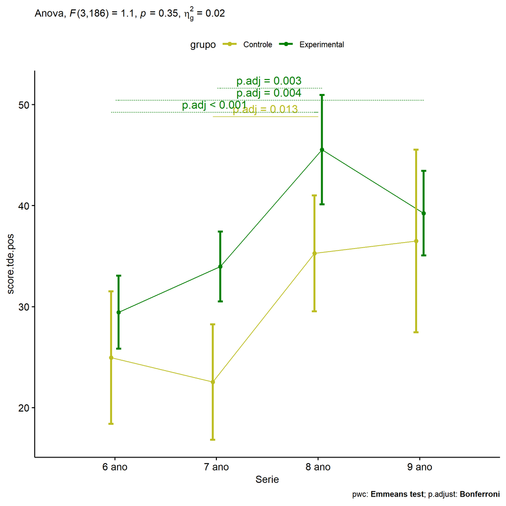

```r
if (!is.null(plots[["Serie"]]))
  plots[["Serie"]] + ggplot2::scale_color_manual(values = color[["grupo"]])
```

```r
plots <- twoWayAncovaBoxPlots(
  wdat, "score.tde.pos", c("grupo","Serie"), aov, pwcs, covar = "score.tde.pre",
  theme = "classic", color = color[["grupo:Serie"]],
  subtitle = which(aov$Effect == "grupo:Serie"))
```

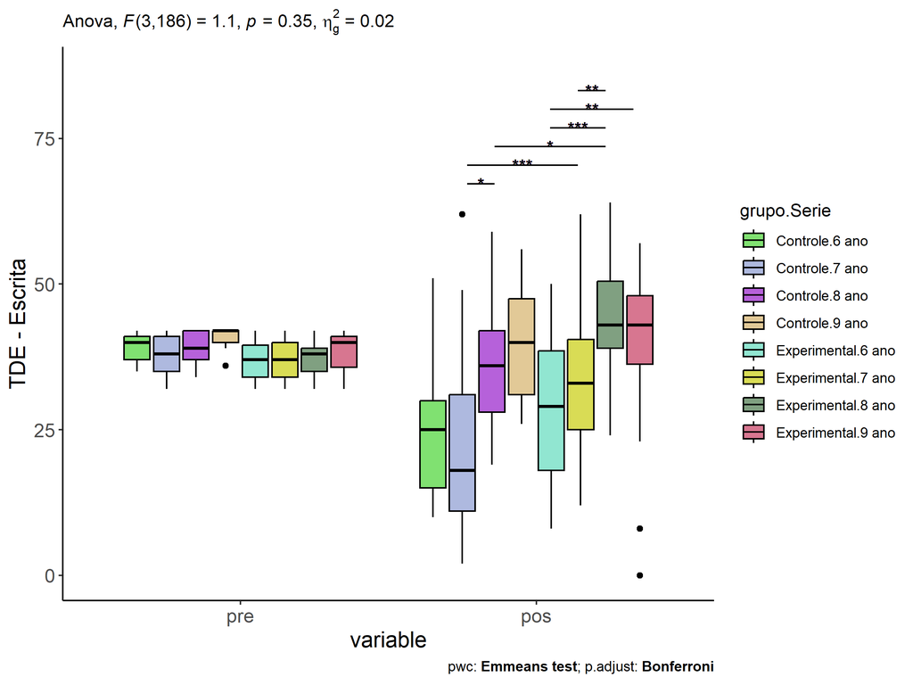

```r
plots[["grupo:Serie"]] + ggplot2::ylab("TDE - Escrita") + ggplot2::scale_x_discrete(labels=c('pre', 'pos'))
```

```r
plots <- twoWayAncovaBoxPlots(
  wdat.long, "score.tde", c("grupo","Serie"), aov, pwc.long, pre.post = "time",
  theme = "classic", color = color$prepost)
```

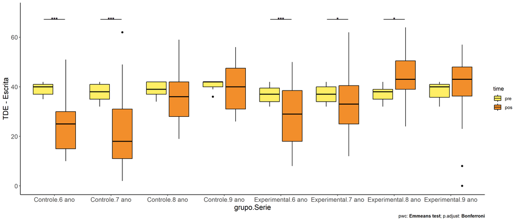

```r
plots[["grupo:Serie"]] + ggplot2::ylab("TDE - Escrita")
```

### Checking linearity assumption

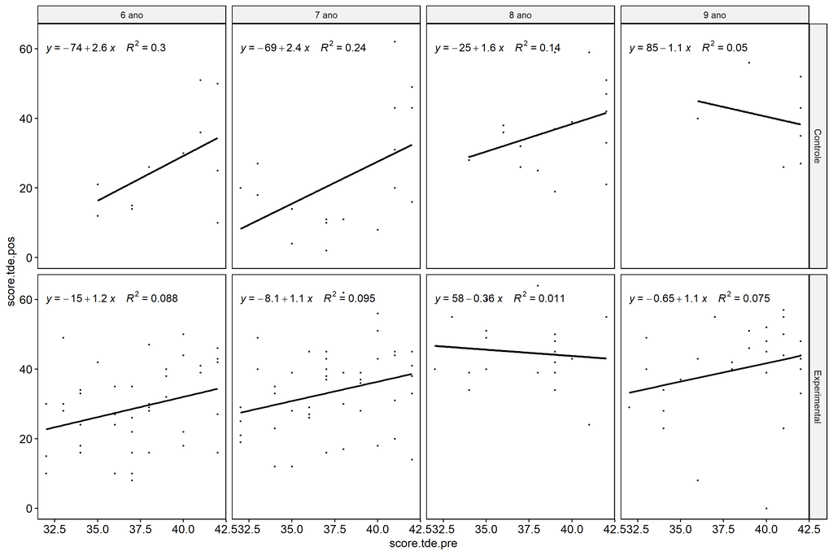

```r
ggscatter(wdat, x = "score.tde.pre", y = "score.tde.pos", size = 0.5,
          facet.by = c("grupo","Serie"), add = "reg.line")+
  stat_regline_equation(
    aes(label =  paste(..eq.label.., ..rr.label.., sep = "~~~~"))
  )
```

### Checking normality and homogeneity

```r
res <- augment(lm(score.tde.pos ~ score.tde.pre + grupo*Serie, data = wdat))
```

```r
shapiro_test(res$.resid)
```

```
## # A tibble: 1 × 3
##   variable   statistic p.value
##   <chr>          <dbl>   <dbl>
## 1 res$.resid     0.993   0.498
```

```r
levene_test(res, .resid ~ grupo*Serie)
```

```
## # A tibble: 1 × 4
##     df1   df2 statistic     p
##   <int> <int>     <dbl> <dbl>
## 1     7   187     0.714 0.661
```

# Summary of Results

## Descriptive Statistics

```r
df <- get.descriptives(ldat[["grupo"]], c(dv.pre, dv.pos), c("grupo"),
                       include.global = T, symmetry.test = T, normality.test = F)
df <- plyr::rbind.fill(
  df, do.call(plyr::rbind.fill, lapply(lfatores2, FUN = function(f) {
    if (nrow(dat) > 0 && sum(!is.na(unique(dat[[f]]))) > 1)
      get.descriptives(ldat[[paste0("grupo:",f)]], c(dv.pre,dv.pos), c("grupo", f),
                       symmetry.test = T, normality.test = F)
    }))
)
(df <- df[,c(fatores1[fatores1 %in% colnames(df)],"variable",
             colnames(df)[!colnames(df) %in% c(fatores1,"variable")])])
```

```
##           grupo Sexo   Zona Cor.Raca Serie      variable   n   mean median min max     sd    se     ci
## 1      Controle <NA>   <NA>     <NA>  <NA> score.tde.pre  54 38.815   39.5  32  42  3.004 0.409  0.820
## 2  Experimental <NA>   <NA>     <NA>  <NA> score.tde.pre 141 37.383   38.0  32  42  3.177 0.268  0.529
## 3          <NA> <NA>   <NA>     <NA>  <NA> score.tde.pre 195 37.779   38.0  32  42  3.188 0.228  0.450
## 4      Controle <NA>   <NA>     <NA>  <NA> score.tde.pos  54 30.185   28.5   2  62 15.298 2.082  4.176
## 5  Experimental <NA>   <NA>     <NA>  <NA> score.tde.pos 141 34.872   37.0   0  64 13.013 1.096  2.167
## 6          <NA> <NA>   <NA>     <NA>  <NA> score.tde.pos 195 33.574   35.0   0  64 13.804 0.989  1.950
## 7      Controle    F   <NA>     <NA>  <NA> score.tde.pre  36 39.167   40.5  33  42  3.019 0.503  1.021
## 8      Controle    M   <NA>     <NA>  <NA> score.tde.pre  18 38.111   38.0  32  42  2.928 0.690  1.456
## 9  Experimental    F   <NA>     <NA>  <NA> score.tde.pre  61 37.557   38.0  32  42  3.101 0.397  0.794
## 10 Experimental    M   <NA>     <NA>  <NA> score.tde.pre  80 37.250   37.0  32  42  3.247 0.363  0.723
## 11     Controle    F   <NA>     <NA>  <NA> score.tde.pos  36 31.444   29.5   4  62 16.366 2.728  5.538
## 12     Controle    M   <NA>     <NA>  <NA> score.tde.pos  18 27.667   26.5   2  51 12.966 3.056  6.448
## 13 Experimental    F   <NA>     <NA>  <NA> score.tde.pos  61 36.934   39.0   0  64 14.477 1.854  3.708
## 14 Experimental    M   <NA>     <NA>  <NA> score.tde.pos  80 33.300   35.0   8  56 11.623 1.300  2.587
```

[output cut: 79 more lines]

| grupo | Sexo | Zona | Cor.Raca | Serie | variable | n | mean | median | min | max | sd | se | ci | iqr | symmetry | skewness | kurtosis |
| --- | --- | --- | --- | --- | --- | --- | --- | --- | --- | --- | --- | --- | --- | --- | --- | --- | --- |
| Controle |  |  |  |  | score.tde.pre | 54 | 38.815 | 39.5 | 32 | 42 | 3.004 | 0.409 | 0.820 | 5.00 | NO | -0.510 | -1.049 |
| Experimental |  |  |  |  | score.tde.pre | 141 | 37.383 | 38.0 | 32 | 42 | 3.177 | 0.268 | 0.529 | 6.00 | YES | -0.147 | -1.221 |
|  |  |  |  |  | score.tde.pre | 195 | 37.779 | 38.0 | 32 | 42 | 3.188 | 0.228 | 0.450 | 6.00 | YES | -0.246 | -1.183 |
| Controle |  |  |  |  | score.tde.pos | 54 | 30.185 | 28.5 | 2 | 62 | 15.298 | 2.082 | 4.176 | 22.25 | YES | 0.232 | -0.869 |
| Experimental |  |  |  |  | score.tde.pos | 141 | 34.872 | 37.0 | 0 | 64 | 13.013 | 1.096 | 2.167 | 18.00 | YES | -0.298 | -0.483 |
|  |  |  |  |  | score.tde.pos | 195 | 33.574 | 35.0 | 0 | 64 | 13.804 | 0.989 | 1.950 | 19.00 | YES | -0.163 | -0.671 |
| Controle | F |  |  |  | score.tde.pre | 36 | 39.167 | 40.5 | 33 | 42 | 3.019 | 0.503 | 1.021 | 6.00 | NO | -0.609 | -1.239 |
| Controle | M |  |  |  | score.tde.pre | 18 | 38.111 | 38.0 | 32 | 42 | 2.928 | 0.690 | 1.456 | 3.75 | YES | -0.369 | -0.720 |
| Experimental | F |  |  |  | score.tde.pre | 61 | 37.557 | 38.0 | 32 | 42 | 3.101 | 0.397 | 0.794 | 5.00 | YES | -0.161 | -1.252 |
| Experimental | M |  |  |  | score.tde.pre | 80 | 37.250 | 37.0 | 32 | 42 | 3.247 | 0.363 | 0.723 | 6.00 | YES | -0.125 | -1.254 |
| Controle | F |  |  |  | score.tde.pos | 36 | 31.444 | 29.5 | 4 | 62 | 16.366 | 2.728 | 5.538 | 24.25 | YES | 0.188 | -1.145 |
| Controle | M |  |  |  | score.tde.pos | 18 | 27.667 | 26.5 | 2 | 51 | 12.966 | 3.056 | 6.448 | 15.00 | YES | 0.039 | -0.684 |
| Experimental | F |  |  |  | score.tde.pos | 61 | 36.934 | 39.0 | 0 | 64 | 14.477 | 1.854 | 3.708 | 21.00 | YES | -0.358 | -0.586 |
| Experimental | M |  |  |  | score.tde.pos | 80 | 33.300 | 35.0 | 8 | 56 | 11.623 | 1.300 | 2.587 | 17.00 | YES | -0.430 | -0.648 |
| Controle |  | Rural |  |  | score.tde.pre | 23 | 39.522 | 41.0 | 34 | 42 | 2.998 | 0.625 | 1.296 | 5.50 | NO | -0.660 | -1.418 |
| Controle |  | Urbana |  |  | score.tde.pre | 18 | 37.500 | 37.5 | 32 | 42 | 2.662 | 0.628 | 1.324 | 3.50 | YES | -0.318 | -0.688 |
| Experimental |  | Rural |  |  | score.tde.pre | 64 | 36.719 | 37.0 | 32 | 42 | 3.037 | 0.380 | 0.759 | 5.00 | YES | -0.014 | -1.235 |
| Experimental |  | Urbana |  |  | score.tde.pre | 40 | 38.675 | 39.5 | 33 | 42 | 2.912 | 0.460 | 0.931 | 4.50 | YES | -0.408 | -1.216 |
| Controle |  | Rural |  |  | score.tde.pos | 23 | 33.261 | 35.0 | 2 | 62 | 14.464 | 3.016 | 6.255 | 20.00 | YES | -0.136 | -0.682 |
| Controle |  | Urbana |  |  | score.tde.pos | 18 | 20.722 | 19.0 | 4 | 39 | 10.910 | 2.572 | 5.426 | 17.25 | YES | 0.321 | -1.292 |
| Experimental |  | Rural |  |  | score.tde.pos | 64 | 34.500 | 34.5 | 8 | 64 | 12.866 | 1.608 | 3.214 | 17.75 | YES | 0.113 | -0.508 |
| Experimental |  | Urbana |  |  | score.tde.pos | 40 | 34.075 | 36.5 | 8 | 56 | 13.088 | 2.069 | 4.186 | 18.50 | YES | -0.477 | -0.794 |
| Controle |  |  | Branca |  | score.tde.pre | 6 | 38.167 | 38.5 | 35 | 41 | 2.858 | 1.167 | 2.999 | 5.25 | YES | -0.096 | -2.142 |
| Controle |  |  | Parda |  | score.tde.pre | 22 | 39.045 | 39.5 | 32 | 42 | 3.031 | 0.646 | 1.344 | 5.00 | NO | -0.639 | -0.759 |
| Experimental |  |  | Branca |  | score.tde.pre | 15 | 37.867 | 38.0 | 32 | 42 | 3.137 | 0.810 | 1.737 | 5.00 | YES | -0.339 | -1.377 |
| Experimental |  |  | Parda |  | score.tde.pre | 34 | 37.147 | 38.0 | 32 | 42 | 2.904 | 0.498 | 1.013 | 4.00 | YES | -0.149 | -0.978 |
| Controle |  |  | Branca |  | score.tde.pos | 6 | 25.667 | 25.0 | 10 | 43 | 15.188 | 6.200 | 15.939 | 25.75 | YES | 0.033 | -2.227 |
| Controle |  |  | Parda |  | score.tde.pos | 22 | 29.273 | 28.0 | 2 | 59 | 18.362 | 3.915 | 8.141 | 28.75 | YES | 0.200 | -1.378 |
| Experimental |  |  | Branca |  | score.tde.pos | 15 | 37.667 | 40.0 | 10 | 64 | 14.316 | 3.696 | 7.928 | 18.00 | YES | -0.183 | -0.841 |
| Experimental |  |  | Parda |  | score.tde.pos | 34 | 32.853 | 31.5 | 8 | 62 | 14.347 | 2.460 | 5.006 | 18.50 | YES | 0.145 | -0.761 |
| Controle |  |  |  | 6 ano | score.tde.pre | 13 | 38.846 | 40.0 | 35 | 42 | 2.794 | 0.775 | 1.689 | 4.00 | YES | -0.235 | -1.708 |
| Controle |  |  |  | 7 ano | score.tde.pre | 17 | 38.059 | 38.0 | 32 | 42 | 3.491 | 0.847 | 1.795 | 6.00 | YES | -0.345 | -1.465 |
| Controle |  |  |  | 8 ano | score.tde.pre | 17 | 38.824 | 39.0 | 34 | 42 | 2.811 | 0.682 | 1.446 | 5.00 | YES | -0.291 | -1.338 |
| Controle |  |  |  | 9 ano | score.tde.pre | 7 | 40.571 | 42.0 | 36 | 42 | 2.299 | 0.869 | 2.126 | 2.00 | NO | -1.031 | -0.650 |
| Experimental |  |  |  | 6 ano | score.tde.pre | 43 | 37.116 | 37.0 | 32 | 42 | 3.064 | 0.467 | 0.943 | 5.50 | YES | 0.009 | -1.121 |
| Experimental |  |  |  | 7 ano | score.tde.pre | 47 | 37.043 | 37.0 | 32 | 42 | 3.257 | 0.475 | 0.956 | 6.00 | YES | -0.048 | -1.247 |
| Experimental |  |  |  | 8 ano | score.tde.pre | 19 | 37.158 | 38.0 | 32 | 42 | 2.892 | 0.663 | 1.394 | 4.00 | YES | -0.175 | -1.348 |
| Experimental |  |  |  | 9 ano | score.tde.pre | 32 | 38.375 | 40.0 | 32 | 42 | 3.309 | 0.585 | 1.193 | 5.25 | NO | -0.553 | -1.237 |
| Controle |  |  |  | 6 ano | score.tde.pos | 13 | 26.231 | 25.0 | 10 | 51 | 13.230 | 3.669 | 7.995 | 15.00 | NO | 0.630 | -0.852 |
| Controle |  |  |  | 7 ano | score.tde.pos | 17 | 22.882 | 18.0 | 2 | 62 | 17.201 | 4.172 | 8.844 | 20.00 | NO | 0.795 | -0.593 |
| Controle |  |  |  | 8 ano | score.tde.pos | 17 | 36.529 | 36.0 | 19 | 59 | 12.047 | 2.922 | 6.194 | 14.00 | YES | 0.472 | -0.882 |
| Controle |  |  |  | 9 ano | score.tde.pos | 7 | 39.857 | 40.0 | 26 | 56 | 11.539 | 4.361 | 10.672 | 16.50 | YES | 0.105 | -1.755 |
| Experimental |  |  |  | 6 ano | score.tde.pos | 43 | 28.651 | 29.0 | 8 | 50 | 12.002 | 1.830 | 3.694 | 20.50 | YES | -0.052 | -1.091 |
| Experimental |  |  |  | 7 ano | score.tde.pos | 47 | 33.085 | 33.0 | 12 | 62 | 11.738 | 1.712 | 3.446 | 15.50 | YES | 0.095 | -0.583 |
| Experimental |  |  |  | 8 ano | score.tde.pos | 19 | 44.789 | 43.0 | 24 | 64 | 9.790 | 2.246 | 4.719 | 11.50 | YES | 0.050 | -0.522 |
| Experimental |  |  |  | 9 ano | score.tde.pos | 32 | 39.969 | 43.0 | 0 | 57 | 12.800 | 2.263 | 4.615 | 11.75 | NO | -1.358 | 1.721 |

## ANCOVA Table Comparison

```r
df <- do.call(plyr::rbind.fill, laov)
(df <- df[!duplicated(df$Effect),])
```

```
##            Effect DFn DFd      F        p p<.05      ges DFn' DFd'     F'       p' p<.05'     ges'
## 1           grupo   1 192  9.837 2.00e-03     * 0.049000    1  192  9.837 2.00e-03      * 0.049000
## 2   score.tde.pre   1 192 21.357 6.98e-06     * 0.100000    1  192 21.357 6.98e-06      * 0.100000
## 4      grupo:Sexo   1 190  0.039 8.43e-01       0.000208    1  190  0.039 8.43e-01        0.000208
## 6            Sexo   1 190  2.468 1.18e-01       0.013000    1  190  2.468 1.18e-01        0.013000
## 8      grupo:Zona   1 140  1.558 2.14e-01       0.011000    1  140  1.558 2.14e-01        0.011000
## 10           Zona   1 140  6.441 1.20e-02     * 0.044000    1  140  6.441 1.20e-02      * 0.044000
## 11       Cor.Raca   1  72  0.220 6.41e-01       0.003000    1   72  0.220 6.41e-01        0.003000
## 13 grupo:Cor.Raca   1  72  0.460 5.00e-01       0.006000    1   72  0.460 5.00e-01        0.006000
## 16    grupo:Serie   3 186  1.102 3.49e-01       0.017000    3  186  1.102 3.49e-01        0.017000
## 18          Serie   3 186 12.849 1.15e-07     * 0.172000    3  186 12.849 1.15e-07      * 0.172000
```

|  | Effect | DFn | DFd | F | p | p<.05 | ges | DFn’ | DFd’ | F’ | p’ | p<.05’ | ges’ |
| --- | --- | --- | --- | --- | --- | --- | --- | --- | --- | --- | --- | --- | --- |
| 1 | grupo | 1 | 192 | 9.837 | 0.002 | * | 0.049 | 1 | 192 | 9.837 | 0.002 | * | 0.049 |
| 2 | score.tde.pre | 1 | 192 | 21.357 | 0.000 | * | 0.100 | 1 | 192 | 21.357 | 0.000 | * | 0.100 |
| 4 | grupo:Sexo | 1 | 190 | 0.039 | 0.843 |  | 0.000 | 1 | 190 | 0.039 | 0.843 |  | 0.000 |
| 6 | Sexo | 1 | 190 | 2.468 | 0.118 |  | 0.013 | 1 | 190 | 2.468 | 0.118 |  | 0.013 |
| 8 | grupo:Zona | 1 | 140 | 1.558 | 0.214 |  | 0.011 | 1 | 140 | 1.558 | 0.214 |  | 0.011 |
| 10 | Zona | 1 | 140 | 6.441 | 0.012 | * | 0.044 | 1 | 140 | 6.441 | 0.012 | * | 0.044 |
| 11 | Cor.Raca | 1 | 72 | 0.220 | 0.641 |  | 0.003 | 1 | 72 | 0.220 | 0.641 |  | 0.003 |
| 13 | grupo:Cor.Raca | 1 | 72 | 0.460 | 0.500 |  | 0.006 | 1 | 72 | 0.460 | 0.500 |  | 0.006 |
| 16 | grupo:Serie | 3 | 186 | 1.102 | 0.349 |  | 0.017 | 3 | 186 | 1.102 | 0.349 |  | 0.017 |
| 18 | Serie | 3 | 186 | 12.849 | 0.000 | * | 0.172 | 3 | 186 | 12.849 | 0.000 | * | 0.172 |

## PairWise Table Comparison

```r
df <- do.call(plyr::rbind.fill, lpwc)
df <- df[,c(names(lfatores), names(df)[!names(df) %in% c(names(lfatores),"term",".y.")])]
```

| grupo | Sexo | Zona | Cor.Raca | Serie | group1 | group2 | df | statistic | p | p.adj | p.adj.signif | df’ | statistic’ | p’ | p.adj’ | p.adj.signif’ |
| --- | --- | --- | --- | --- | --- | --- | --- | --- | --- | --- | --- | --- | --- | --- | --- | --- |
| Controle |  |  |  |  | pre | pos | 386 | 4.519 | 0.000 | 0.000 | **** | 386 | 4.519 | 0.000 | 0.000 | **** |
| Experimental |  |  |  |  | pre | pos | 386 | 2.125 | 0.034 | 0.034 | * | 386 | 2.125 | 0.034 | 0.034 | * |
|  |  |  |  |  | Controle | Experimental | 192 | -3.136 | 0.002 | 0.002 | ** | 192 | -3.136 | 0.002 | 0.002 | ** |
| Controle | F |  |  |  | pre | pos | 382 | 3.313 | 0.001 | 0.001 | ** | 382 | 3.313 | 0.001 | 0.001 | ** |
| Controle | M |  |  |  | pre | pos | 382 | 3.169 | 0.002 | 0.002 | ** | 382 | 3.169 | 0.002 | 0.002 | ** |
| Controle |  |  |  |  | F | M | 190 | 0.626 | 0.532 | 0.532 | ns | 190 | 0.626 | 0.532 | 0.532 | ns |
| Experimental | F |  |  |  | pre | pos | 382 | 0.348 | 0.728 | 0.728 | ns | 382 | 0.348 | 0.728 | 0.728 | ns |
| Experimental | M |  |  |  | pre | pos | 382 | 2.526 | 0.012 | 0.012 | * | 382 | 2.526 | 0.012 | 0.012 | * |
| Experimental |  |  |  |  | F | M | 190 | 1.457 | 0.147 | 0.147 | ns | 190 | 1.457 | 0.147 | 0.147 | ns |
|  | F |  |  |  | Controle | Experimental | 190 | -2.762 | 0.006 | 0.006 | ** | 190 | -2.762 | 0.006 | 0.006 | ** |
|  | M |  |  |  | Controle | Experimental | 190 | -1.999 | 0.047 | 0.047 | * | 190 | -1.999 | 0.047 | 0.047 | * |
| Controle |  |  |  |  | Rural | Urbana | 140 | 2.412 | 0.017 | 0.017 | * | 140 | 2.412 | 0.017 | 0.017 | * |
| Controle |  | Rural |  |  | pre | pos | 282 | 2.257 | 0.025 | 0.025 | * | 282 | 2.257 | 0.025 | 0.025 | * |
| Controle |  | Urbana |  |  | pre | pos | 282 | 5.350 | 0.000 | 0.000 | **** | 282 | 5.350 | 0.000 | 0.000 | **** |
| Experimental |  |  |  |  | Rural | Urbana | 140 | 1.359 | 0.176 | 0.176 | ns | 140 | 1.359 | 0.176 | 0.176 | ns |
| Experimental |  | Rural |  |  | pre | pos | 282 | 1.334 | 0.183 | 0.183 | ns | 282 | 1.334 | 0.183 | 0.183 | ns |
| Experimental |  | Urbana |  |  | pre | pos | 282 | 2.186 | 0.030 | 0.030 | * | 282 | 2.186 | 0.030 | 0.030 | * |
|  |  | Rural |  |  | Controle | Experimental | 140 | -1.793 | 0.075 | 0.075 | ns | 140 | -1.793 | 0.075 | 0.075 | ns |
|  |  | Urbana |  |  | Controle | Experimental | 140 | -3.312 | 0.001 | 0.001 | ** | 140 | -3.312 | 0.001 | 0.001 | ** |
| Controle |  |  | Branca |  | pre | pos | 146 | 1.921 | 0.057 | 0.057 | ns | 146 | 1.921 | 0.057 | 0.057 | ns |
| Controle |  |  |  |  | Branca | Parda | 72 | -0.302 | 0.763 | 0.763 | ns | 72 | -0.302 | 0.763 | 0.763 | ns |
| Controle |  |  | Parda |  | pre | pos | 146 | 2.876 | 0.005 | 0.005 | ** | 146 | 2.876 | 0.005 | 0.005 | ** |
| Experimental |  |  | Branca |  | pre | pos | 146 | 0.049 | 0.961 | 0.961 | ns | 146 | 0.049 | 0.961 | 0.961 | ns |
| Experimental |  |  |  |  | Branca | Parda | 72 | 0.769 | 0.444 | 0.444 | ns | 72 | 0.769 | 0.444 | 0.444 | ns |
| Experimental |  |  | Parda |  | pre | pos | 146 | 1.571 | 0.118 | 0.118 | ns | 146 | 1.571 | 0.118 | 0.118 | ns |
|  |  |  | Branca |  | Controle | Experimental | 72 | -1.743 | 0.086 | 0.086 | ns | 72 | -1.743 | 0.086 | 0.086 | ns |
|  |  |  | Parda |  | Controle | Experimental | 72 | -1.632 | 0.107 | 0.107 | ns | 72 | -1.632 | 0.107 | 0.107 | ns |
| Controle |  |  |  | 6 ano | pre | pos | 374 | 3.535 | 0.000 | 0.000 | *** | 374 | 3.535 | 0.000 | 0.000 | *** |
| Controle |  |  |  | 7 ano | pre | pos | 374 | 4.863 | 0.000 | 0.000 | **** | 374 | 4.863 | 0.000 | 0.000 | **** |
| Controle |  |  |  | 8 ano | pre | pos | 374 | 0.735 | 0.463 | 0.463 | ns | 374 | 0.735 | 0.463 | 0.463 | ns |
| Controle |  |  |  | 9 ano | pre | pos | 374 | 0.147 | 0.883 | 0.883 | ns | 374 | 0.147 | 0.883 | 0.883 | ns |
| Controle |  |  |  |  | 6 ano | 7 ano | 186 | 0.546 | 0.586 | 1.000 | ns | 186 | 0.546 | 0.586 | 1.000 | ns |
| Controle |  |  |  |  | 6 ano | 8 ano | 186 | -2.347 | 0.020 | 0.120 | ns | 186 | -2.347 | 0.020 | 0.120 | ns |
| Controle |  |  |  |  | 6 ano | 9 ano | 186 | -2.056 | 0.041 | 0.247 | ns | 186 | -2.056 | 0.041 | 0.247 | ns |
| Controle |  |  |  |  | 7 ano | 8 ano | 186 | -3.103 | 0.002 | 0.013 | * | 186 | -3.103 | 0.002 | 0.013 | * |
| Controle |  |  |  |  | 7 ano | 9 ano | 186 | -2.581 | 0.011 | 0.064 | ns | 186 | -2.581 | 0.011 | 0.064 | ns |
| Controle |  |  |  |  | 8 ano | 9 ano | 186 | -0.228 | 0.820 | 1.000 | ns | 186 | -0.228 | 0.820 | 1.000 | ns |
| Experimental |  |  |  | 6 ano | pre | pos | 374 | 4.314 | 0.000 | 0.000 | **** | 374 | 4.314 | 0.000 | 0.000 | **** |
| Experimental |  |  |  | 7 ano | pre | pos | 374 | 2.108 | 0.036 | 0.036 | * | 374 | 2.108 | 0.036 | 0.036 | * |
| Experimental |  |  |  | 8 ano | pre | pos | 374 | -2.585 | 0.010 | 0.010 | * | 374 | -2.585 | 0.010 | 0.010 | * |
| Experimental |  |  |  | 9 ano | pre | pos | 374 | -0.701 | 0.484 | 0.484 | ns | 374 | -0.701 | 0.484 | 0.484 | ns |
| Experimental |  |  |  |  | 6 ano | 7 ano | 186 | -1.794 | 0.074 | 0.446 | ns | 186 | -1.794 | 0.074 | 0.446 | ns |
| Experimental |  |  |  |  | 6 ano | 8 ano | 186 | -4.890 | 0.000 | 0.000 | **** | 186 | -4.890 | 0.000 | 0.000 | **** |
| Experimental |  |  |  |  | 6 ano | 9 ano | 186 | -3.490 | 0.001 | 0.004 | ** | 186 | -3.490 | 0.001 | 0.004 | ** |
| Experimental |  |  |  |  | 7 ano | 8 ano | 186 | -3.562 | 0.000 | 0.003 | ** | 186 | -3.562 | 0.000 | 0.003 | ** |
| Experimental |  |  |  |  | 7 ano | 9 ano | 186 | -1.913 | 0.057 | 0.344 | ns | 186 | -1.913 | 0.057 | 0.344 | ns |
| Experimental |  |  |  |  | 8 ano | 9 ano | 186 | 1.807 | 0.072 | 0.434 | ns | 186 | 1.807 | 0.072 | 0.434 | ns |
|  |  |  |  | 6 ano | Controle | Experimental | 186 | -1.180 | 0.240 | 0.240 | ns | 186 | -1.180 | 0.240 | 0.240 | ns |
|  |  |  |  | 7 ano | Controle | Experimental | 186 | -3.368 | 0.001 | 0.001 | *** | 186 | -3.368 | 0.001 | 0.001 | *** |
|  |  |  |  | 8 ano | Controle | Experimental | 186 | -2.556 | 0.011 | 0.011 | * | 186 | -2.556 | 0.011 | 0.011 | * |
|  |  |  |  | 9 ano | Controle | Experimental | 186 | -0.547 | 0.585 | 0.585 | ns | 186 | -0.547 | 0.585 | 0.585 | ns |

## EMMS Table Comparison

```r
df <- do.call(plyr::rbind.fill, lemms)
df[["N-N'"]] <- df[["N"]] - df[["N'"]]
df <- df[,c(names(lfatores), names(df)[!names(df) %in% names(lfatores)])]
```

| grupo | Sexo | Zona | Cor.Raca | Serie | N | M (pre) | SE (pre) | M (unadj) | SE (unadj) | M (adj) | SE (adj) | N’ | M (pre)’ | SE (pre)’ | M (unadj)’ | SE (unadj)’ | M (adj)’ | SE (adj)’ | N-N’ |
| --- | --- | --- | --- | --- | --- | --- | --- | --- | --- | --- | --- | --- | --- | --- | --- | --- | --- | --- | --- |
| Controle |  |  |  |  | 54 | 38.815 | 0.409 | 30.185 | 2.082 | 28.754 | 1.797 | 54 | 38.815 | 0.409 | 30.185 | 2.082 | 28.754 | 1.797 | 0 |
| Experimental |  |  |  |  | 141 | 37.383 | 0.268 | 34.872 | 1.096 | 35.420 | 1.102 | 141 | 37.383 | 0.268 | 34.872 | 1.096 | 35.420 | 1.102 | 0 |
| Controle | F |  |  |  | 36 | 39.167 | 0.503 | 31.444 | 2.728 | 29.574 | 2.205 | 36 | 39.167 | 0.503 | 31.444 | 2.728 | 29.574 | 2.205 | 0 |
| Controle | M |  |  |  | 18 | 38.111 | 0.690 | 27.667 | 3.056 | 27.219 | 3.064 | 18 | 38.111 | 0.690 | 27.667 | 3.056 | 27.219 | 3.064 | 0 |
| Experimental | F |  |  |  | 61 | 37.557 | 0.397 | 36.934 | 1.854 | 37.234 | 1.665 | 61 | 37.557 | 0.397 | 36.934 | 1.854 | 37.234 | 1.665 | 0 |
| Experimental | M |  |  |  | 80 | 37.250 | 0.363 | 33.300 | 1.300 | 34.014 | 1.461 | 80 | 37.250 | 0.363 | 33.300 | 1.300 | 34.014 | 1.461 | 0 |
| Controle |  | Rural |  |  | 23 | 39.522 | 0.625 | 33.261 | 3.016 | 30.588 | 2.609 | 23 | 39.522 | 0.625 | 33.261 | 3.016 | 30.588 | 2.609 | 0 |
| Controle |  | Urbana |  |  | 18 | 37.500 | 0.628 | 20.722 | 2.572 | 21.188 | 2.873 | 18 | 37.500 | 0.628 | 20.722 | 2.572 | 21.188 | 2.873 | 0 |
| Experimental |  | Rural |  |  | 64 | 36.719 | 0.380 | 34.500 | 1.608 | 36.179 | 1.568 | 64 | 36.719 | 0.380 | 34.500 | 1.608 | 36.179 | 1.568 | 0 |
| Experimental |  | Urbana |  |  | 40 | 38.675 | 0.460 | 34.075 | 2.069 | 32.717 | 1.950 | 40 | 38.675 | 0.460 | 34.075 | 2.069 | 32.717 | 1.950 | 0 |
| Controle |  |  | Branca |  | 6 | 38.167 | 1.167 | 25.667 | 6.200 | 25.218 | 6.074 | 6 | 38.167 | 1.167 | 25.667 | 6.200 | 25.218 | 6.074 | 0 |
| Controle |  |  | Parda |  | 22 | 39.045 | 0.646 | 29.273 | 3.915 | 27.295 | 3.239 | 22 | 39.045 | 0.646 | 29.273 | 3.915 | 27.295 | 3.239 | 0 |
| Experimental |  |  | Branca |  | 15 | 37.867 | 0.810 | 37.667 | 3.696 | 37.741 | 3.840 | 15 | 37.867 | 0.810 | 37.667 | 3.696 | 37.741 | 3.840 | 0 |
| Experimental |  |  | Parda |  | 34 | 37.147 | 0.498 | 32.853 | 2.460 | 34.179 | 2.589 | 34 | 37.147 | 0.498 | 32.853 | 2.460 | 34.179 | 2.589 | 0 |
| Controle |  |  |  | 6 ano | 13 | 38.846 | 0.775 | 26.231 | 3.669 | 24.951 | 3.326 | 13 | 38.846 | 0.775 | 26.231 | 3.669 | 24.951 | 3.326 | 0 |
| Controle |  |  |  | 7 ano | 17 | 38.059 | 0.847 | 22.882 | 4.172 | 22.547 | 2.897 | 17 | 38.059 | 0.847 | 22.882 | 4.172 | 22.547 | 2.897 | 0 |
| Controle |  |  |  | 8 ano | 17 | 38.824 | 0.682 | 36.529 | 2.922 | 35.276 | 2.911 | 17 | 38.824 | 0.682 | 36.529 | 2.922 | 35.276 | 2.911 | 0 |
| Controle |  |  |  | 9 ano | 7 | 40.571 | 0.869 | 39.857 | 4.361 | 36.506 | 4.581 | 7 | 40.571 | 0.869 | 39.857 | 4.361 | 36.506 | 4.581 | 0 |
| Experimental |  |  |  | 6 ano | 43 | 37.116 | 0.467 | 28.651 | 1.830 | 29.447 | 1.831 | 43 | 37.116 | 0.467 | 28.651 | 1.830 | 29.447 | 1.831 | 0 |
| Experimental |  |  |  | 7 ano | 47 | 37.043 | 0.475 | 33.085 | 1.712 | 33.970 | 1.754 | 47 | 37.043 | 0.475 | 33.085 | 1.712 | 33.970 | 1.754 | 0 |
| Experimental |  |  |  | 8 ano | 19 | 37.158 | 0.663 | 44.789 | 2.246 | 45.535 | 2.745 | 19 | 37.158 | 0.663 | 44.789 | 2.246 | 45.535 | 2.745 | 0 |
| Experimental |  |  |  | 9 ano | 32 | 38.375 | 0.585 | 39.969 | 2.263 | 39.254 | 2.118 | 32 | 38.375 | 0.585 | 39.969 | 2.263 | 39.254 | 2.118 | 0 |